# Exploring Bay Wheels Trip Data

## Preliminary Wrangling

> Bay Wheels is a regional public bicycle sharing system in the San Francisco Bay Area, California. It was established as Bay Area Bike Share in August 2013. 2017, the system officially re-launched as Ford GoBike in a partnership with Ford Motor Company and After acquisition by Lyft, the system was renamed to Bay Wheels in June 2019. Bay Wheels is the first regional and large-scale bicycle sharing system deployed in California and on the West Coast of the United States.

> The bicycles are available 24 hours a day, seven days a week for periods ranging from a single ride (up to 30 minutes) to a day pass, in 30-minute increments, or customers can purchase an annual subscription which gives them unlimited rides up to 45-minutes in duration. A reduced pricing option called "Bike Share for All" exists for users who qualify for CalFresh, the SFMTA's Lifeline pass, or PG & E's CARE discount. This membership option provides rides of 60 minutes without an additional charge.

> The used dataset consists of trip dates from January 2018 until July 2019. It provides informations about the start and end stations of the trips, start and end times of the trips, informations of the users as gender and birth year and the kind of user membership. The trip data can be downloaded from https://www.lyft.com/bikes/bay-wheels/system-data

```python
# import all packages and set plots to be embedded inline

import os
import requests
import zipfile

import numpy as np
import pandas as pd
import datetime as dt


import matplotlib.pyplot as plt
import seaborn as sns


%matplotlib inline
```

# download the files from Jan 2018 until July 2019

# store under \data2\

# year 2018

for x in range(201801, 201813): url = f"https://s3.amazonaws.com/baywheels-data/{x}-fordgobike-tripdata.csv.zip" response = requests.get(url) with open(f'data2{x}-fordgobike-tripdata.csv.zip', mode = 'wb') as file: file.write(response.content) print(x) # to see what happens

# year 2019 until April

for y in range(201901, 201905): url = f"https://s3.amazonaws.com/baywheels-data/{y}-fordgobike-tripdata.csv.zip" response = requests.get(url) with open(f'data2{y}-fordgobike-tripdata.csv.zip', mode = 'wb') as file: file.write(response.content) print(y) # to see what happens

# Mai to July 2019

for z in range(201905, 201908): url = f"https://s3.amazonaws.com/baywheels-data/{z}-baywheels-tripdata.csv.zip" response = requests.get(url) with open(f'data2{z}-baywheels-tripdata.csv.zip', mode = 'wb') as file: file.write(response.content) print(z) # to see what happens

##### this cell was set to markdown since it is not necessary to run again

```python
os.listdir('data2')
```

```
['201801-fordgobike-tripdata.csv.zip',
 '201802-fordgobike-tripdata.csv.zip',
 '201803-fordgobike-tripdata.csv.zip',
 '201804-fordgobike-tripdata.csv.zip',
 '201805-fordgobike-tripdata.csv.zip',
 '201806-fordgobike-tripdata.csv.zip',
 '201807-fordgobike-tripdata.csv.zip',
 '201808-fordgobike-tripdata.csv.zip',
 '201809-fordgobike-tripdata.csv.zip',
 '201810-fordgobike-tripdata.csv.zip',
 '201811-fordgobike-tripdata.csv.zip',
 '201812-fordgobike-tripdata.csv.zip',
 '201901-fordgobike-tripdata.csv.zip',
 '201902-fordgobike-tripdata.csv.zip',
 '201903-fordgobike-tripdata.csv.zip',
 '201904-fordgobike-tripdata.csv.zip',
 '201905-baywheels-tripdata.csv.zip',
 '201906-baywheels-tripdata.csv.zip',
 '201907-baywheels-tripdata.csv.zip']
```

```python
# extracting zipfiles and creating dataframes
frames = []
for file in os.listdir('data2'):

    zf = zipfile.ZipFile(f'data2/{file}')
    df = pd.read_csv(zf.open(file[:-4]))
    frames.append(df)

# control, should be 19
len(frames)


# zf = zipfile.ZipFile('C:/Users/Desktop/THEZIPFILE.zip')
# df = pd.read_csv(zf.open('intfile.csv'))
# https://stackoverflow.com/questions/26942476/reading-csv-zipped-files-in-python
```

```
19
```

```python
# create one dataframe from all files
alldata = pd.concat(frames, ignore_index=True, sort=False)
alldata.shape
# over 3 mio entries, 18 columns
```

```
(3308432, 18)
```

## Assessing

```python
alldata.sample(20)
```

|  | duration_sec | start_time | end_time | start_station_id | start_station_name | start_station_latitude | start_station_longitude | end_station_id | end_station_name | end_station_latitude | end_station_longitude | bike_id | user_type | member_birth_year | member_gender | bike_share_for_all_trip | rental_access_method | Unnamed: 16 |
| --- | --- | --- | --- | --- | --- | --- | --- | --- | --- | --- | --- | --- | --- | --- | --- | --- | --- | --- |
| 2246187 | 1348 | 2019-03-30 21:48:34.4360 | 2019-03-30 22:11:03.4330 | 175.0 | 49th St at Telegraph Ave | 37.835946 | -122.262366 | 175.0 | 49th St at Telegraph Ave | 37.835946 | -122.262366 | 6663 | Customer | 1983.0 | Other | No | NaN | NaN |
| 1502511 | 166 | 2018-10-15 17:39:42.8610 | 2018-10-15 17:42:29.5040 | 8.0 | The Embarcadero at Vallejo St | 37.799953 | -122.398525 | 16.0 | Steuart St at Market St | 37.794130 | -122.394430 | 150 | Subscriber | 1971.0 | Male | No | NaN | NaN |
| 926824 | 889 | 2018-07-16 08:11:36.5940 | 2018-07-16 08:26:26.4440 | 22.0 | Howard St at Beale St | 37.789756 | -122.394643 | 77.0 | 11th St at Natoma St | 37.773507 | -122.416040 | 3333 | Customer | 1983.0 | Female | No | NaN | NaN |
| 2749333 | 861 | 2019-05-29 19:56:13.0380 | 2019-05-29 20:10:34.9140 | 22.0 | Howard St at Beale St | 37.789756 | -122.394643 | 60.0 | 8th St at Ringold St | 37.774520 | -122.409449 | 3584 | Subscriber | 1995.0 | Female | No | NaN | NaN |
| 2420159 | 1140 | 2019-03-11 18:47:00.4980 | 2019-03-11 19:06:00.6280 | 61.0 | Howard St at 8th St | 37.776513 | -122.411306 | 47.0 | 4th St at Harrison St | 37.780955 | -122.399749 | 908 | Subscriber | 1990.0 | Male | No | NaN | NaN |
| 939764 | 1005 | 2018-07-13 15:50:15.7780 | 2018-07-13 16:07:01.2130 | 67.0 | San Francisco Caltrain Station 2 (Townsend St... | 37.776639 | -122.395526 | 285.0 | Webster St at O'Farrell St | 37.783521 | -122.431158 | 4225 | Customer | 1995.0 | Male | No | NaN | NaN |
| 1603551 | 582 | 2018-11-30 07:41:47.1350 | 2018-11-30 07:51:29.3040 | 90.0 | Townsend St at 7th St | 37.771058 | -122.402717 | 59.0 | S Van Ness Ave at Market St | 37.774814 | -122.418954 | 2284 | Subscriber | 1983.0 | Male | No | NaN | NaN |
| 1907246 | 7615 | 2019-01-26 17:20:38.3490 | 2019-01-26 19:27:33.9370 | 377.0 | Fell St at Stanyan St | 37.771917 | -122.453704 | 4.0 | Cyril Magnin St at Ellis St | 37.785881 | -122.408915 | 1122 | Customer | NaN | NaN | No | NaN | NaN |
| 868415 | 2845 | 2018-07-24 15:19:35.3760 | 2018-07-24 16:07:00.8950 | 15.0 | San Francisco Ferry Building (Harry Bridges Pl... | 37.795392 | -122.394203 | 8.0 | The Embarcadero at Vallejo St | 37.799953 | -122.398525 | 1492 | Customer | 1960.0 | Male | No | NaN | NaN |
| 599553 | 164 | 2018-05-04 16:22:25.5240 | 2018-05-04 16:25:09.5300 | 47.0 | 4th St at Harrison St | 37.780955 | -122.399749 | 47.0 | 4th St at Harrison St | 37.780955 | -122.399749 | 2303 | Subscriber | 1979.0 | Male | No | NaN | NaN |
| 1635509 | 312 | 2018-11-19 21:46:29.8630 | 2018-11-19 21:51:42.0250 | 197.0 | El Embarcadero at Grand Ave | 37.808848 | -122.249680 | 200.0 | 2nd Ave at E 18th St | 37.800214 | -122.253810 | 2880 | Subscriber | 1989.0 | Female | No | NaN | NaN |
| 857907 | 879 | 2018-07-25 18:37:39.8680 | 2018-07-25 18:52:19.5810 | 30.0 | San Francisco Caltrain (Townsend St at 4th St) | 37.776598 | -122.395282 | 6.0 | The Embarcadero at Sansome St | 37.804770 | -122.403234 | 1088 | Subscriber | 1987.0 | Male | No | NaN | NaN |
| 1589430 | 527 | 2018-10-02 09:06:44.5190 | 2018-10-02 09:15:32.2460 | 30.0 | San Francisco Caltrain (Townsend St at 4th St) | 37.776598 | -122.395282 | 25.0 | Howard St at 2nd St | 37.787522 | -122.397405 | 3610 | Subscriber | 1977.0 | Male | No | NaN | NaN |
| 2846901 | 599 | 2019-05-11 20:26:39.9780 | 2019-05-11 20:36:39.2060 | 311.0 | Paseo De San Antonio at 2nd St | 37.333798 | -121.886943 | 296.0 | 5th St at Virginia St | 37.325998 | -121.877120 | 4044 | Subscriber | 1995.0 | Male | Yes | NaN | NaN |
| 711393 | 326 | 2018-06-18 09:32:55.9400 | 2018-06-18 09:38:22.9280 | 67.0 | San Francisco Caltrain Station 2 (Townsend St... | 37.776639 | -122.395526 | 36.0 | Folsom St at 3rd St | 37.783830 | -122.398870 | 2048 | Subscriber | 1982.0 | Male | No | NaN | NaN |
| 2166129 | 522 | 2019-02-12 18:04:00.9190 | 2019-02-12 18:12:43.0240 | 50.0 | 2nd St at Townsend St | 37.780526 | -122.390288 | 21.0 | Montgomery St BART Station (Market St at 2nd St) | 37.789625 | -122.400811 | 4826 | Subscriber | 1992.0 | Male | No | NaN | NaN |
| 1502521 | 834 | 2018-10-15 17:28:07.9800 | 2018-10-15 17:42:01.9930 | 44.0 | Civic Center/UN Plaza BART Station (Market St ... | 37.781074 | -122.411738 | 364.0 | Mission Rock St at 3rd St | 37.772886 | -122.389940 | 1153 | Subscriber | 1989.0 | Female | No | NaN | NaN |
| 1258264 | 700 | 2018-09-23 16:48:17.6710 | 2018-09-23 16:59:57.9100 | 14.0 | Clay St at Battery St | 37.795001 | -122.399970 | 4.0 | Cyril Magnin St at Ellis St | 37.785881 | -122.408915 | 449 | Subscriber | 1995.0 | Male | No | NaN | NaN |
| 211389 | 545 | 2018-03-29 16:20:18.4880 | 2018-03-29 16:29:23.7810 | 90.0 | Townsend St at 7th St | 37.771058 | -122.402717 | 342.0 | Colin P Kelly Jr St at Townsend St (Temporary ... | 37.781383 | -122.389841 | 1780 | Subscriber | 1971.0 | Male | No | NaN | NaN |
| 2466474 | 644 | 2019-03-05 15:54:18.1490 | 2019-03-05 16:05:02.1780 | 21.0 | Montgomery St BART Station (Market St at 2nd St) | 37.789625 | -122.400811 | 81.0 | Berry St at 4th St | 37.775880 | -122.393170 | 5969 | Subscriber | 1985.0 | Female | No | NaN | NaN |

```python
alldata['Unnamed: 16'].value_counts()
```

```
app        25815
clipper     3809
Name: Unnamed: 16, dtype: int64
```

```python
alldata['Unnamed: 16'].isna().sum()
```

```
3278808
```

```python
alldata.rental_access_method.value_counts()
```

```
app        3379
clipper     514
Name: rental_access_method, dtype: int64
```

```python
alldata.bike_share_for_all_trip.value_counts()
```

```
No     2998599
Yes     276316
Name: bike_share_for_all_trip, dtype: int64
```

- The last two columns are not present in the first files. There are to many missing data, so these columns could be eliminated.
- the raw dataset consist of 3308432 rows on 18 columns.
- First check for tidyness and quality issues.

```python
alldata.shape
```

```
(3308432, 18)
```

```python
# visually inspection
df.sample(20)
```

|  | duration_sec | start_time | end_time | start_station_id | start_station_name | start_station_latitude | start_station_longitude | end_station_id | end_station_name | end_station_latitude | end_station_longitude | bike_id | user_type | member_birth_year | member_gender | bike_share_for_all_trip | Unnamed: 16 |
| --- | --- | --- | --- | --- | --- | --- | --- | --- | --- | --- | --- | --- | --- | --- | --- | --- | --- |
| 186555 | 538 | 2019-07-16 08:17:03 | 2019-07-16 08:26:01 | NaN | NaN | 37.808212 | -122.246978 | NaN | NaN | 37.823677 | -122.256220 | 132199 | Subscriber | 1985.0 | F | NaN | app |
| 34967 | 869 | 2019-07-25 09:42:27.6390 | 2019-07-25 09:56:57.1030 | 67.0 | San Francisco Caltrain Station 2 (Townsend St... | 37.776639 | -122.395526 | 23.0 | The Embarcadero at Steuart St | 37.791464 | -122.391034 | 3256 | Customer | NaN | NaN | No | NaN |
| 85707 | 243 | 2019-07-16 08:33:32.6430 | 2019-07-16 08:37:36.3720 | 223.0 | 16th St Mission BART Station 2 | 37.764765 | -122.420091 | 112.0 | Harrison St at 17th St | 37.763847 | -122.413004 | 2835 | Subscriber | 1996.0 | Female | No | NaN |
| 197104 | 428 | 2019-07-23 09:09:19 | 2019-07-23 09:16:27 | 239.0 | Bancroft Way at Telegraph Ave | 37.868813 | -122.258764 | 238.0 | MLK Jr Way at University Ave | 37.871719 | -122.273068 | 127704 | Subscriber | 1991.0 | M | NaN | app |
| 3870 | 1262 | 2019-07-31 15:49:31.1210 | 2019-07-31 16:10:33.1620 | 110.0 | 17th & Folsom Street Park (17th St at Folsom St) | 37.763708 | -122.415204 | 22.0 | Howard St at Beale St | 37.789756 | -122.394643 | 2057 | Subscriber | 1986.0 | Male | No | NaN |
| 37594 | 812 | 2019-07-24 19:12:01.4500 | 2019-07-24 19:25:34.0880 | 13.0 | Commercial St at Montgomery St | 37.794231 | -122.402923 | 62.0 | Victoria Manalo Draves Park | 37.777791 | -122.406432 | 2570 | Customer | NaN | NaN | No | NaN |
| 168437 | 611 | 2019-07-01 09:15:29.7220 | 2019-07-01 09:25:41.2310 | 114.0 | Rhode Island St at 17th St | 37.764478 | -122.402570 | 87.0 | Folsom St at 13th St | 37.769757 | -122.415674 | 3087 | Subscriber | 1991.0 | Male | No | NaN |
| 191416 | 268 | 2019-07-29 19:02:48 | 2019-07-29 19:07:17 | 191.0 | Market St at 40th St | 37.830545 | -122.273937 | NaN | NaN | 37.842484 | -122.272316 | 396408 | Subscriber | NaN | ? | NaN | app |
| 25728 | 766 | 2019-07-27 10:25:11.2550 | 2019-07-27 10:37:57.4710 | 251.0 | California St at University Ave | 37.870555 | -122.279720 | 252.0 | Channing Way at Shattuck Ave | 37.865847 | -122.267443 | 3718 | Subscriber | 1982.0 | Female | No | NaN |
| 32883 | 833 | 2019-07-25 17:55:01.0570 | 2019-07-25 18:08:54.1750 | 61.0 | Howard St at 8th St | 37.776513 | -122.411306 | 384.0 | Jackson St at Polk St | 37.794160 | -122.421568 | 3533 | Subscriber | 1986.0 | Male | No | NaN |
| 114918 | 555 | 2019-07-10 23:54:01.9270 | 2019-07-11 00:03:17.3560 | 282.0 | Market St at Park St | 37.332426 | -121.890349 | 286.0 | San Carlos St at 11th St | 37.336466 | -121.876613 | 187 | Customer | 1968.0 | Female | No | NaN |
| 94610 | 715 | 2019-07-14 18:14:54.3550 | 2019-07-14 18:26:49.4800 | 35.0 | Cahill Park | 37.329119 | -121.904576 | 276.0 | Julian St at The Alameda | 37.332233 | -121.912517 | 7174 | Subscriber | 1998.0 | Male | Yes | NaN |
| 34826 | 913 | 2019-07-25 10:06:26.2100 | 2019-07-25 10:21:39.8690 | 166.0 | College Ave at Alcatraz Ave | 37.851376 | -122.252523 | 243.0 | Bancroft Way at College Ave | 37.869360 | -122.254337 | 3681 | Subscriber | 1972.0 | Female | No | NaN |
| 105479 | 299 | 2019-07-12 10:07:12.8520 | 2019-07-12 10:12:12.3120 | 236.0 | Market St at 8th St | 37.803686 | -122.282497 | 160.0 | West Oakland BART Station | 37.805318 | -122.294837 | 1926 | Subscriber | 1979.0 | Male | No | NaN |
| 76988 | 788 | 2019-07-17 10:37:44.0310 | 2019-07-17 10:50:53.0000 | 16.0 | Steuart St at Market St | 37.794130 | -122.394430 | 364.0 | China Basin St at 3rd St | 37.772000 | -122.389970 | 1416 | Subscriber | 1977.0 | Male | No | NaN |
| 136078 | 657 | 2019-07-08 07:59:42.6400 | 2019-07-08 08:10:40.5240 | 16.0 | Steuart St at Market St | 37.794130 | -122.394430 | 30.0 | San Francisco Caltrain (Townsend St at 4th St) | 37.776598 | -122.395282 | 1744 | Customer | NaN | NaN | No | NaN |
| 71601 | 1236 | 2019-07-18 07:59:25.7080 | 2019-07-18 08:20:01.9070 | 107.0 | 17th St at Dolores St | 37.763015 | -122.426497 | 49.0 | S Park St at 3rd St | 37.780760 | -122.394989 | 238 | Subscriber | 1989.0 | Female | No | NaN |
| 185949 | 466 | 2019-07-29 07:15:46 | 2019-07-29 07:23:33 | NaN | NaN | 37.805562 | -122.296204 | NaN | NaN | 37.817765 | -122.292369 | 238875 | Customer | NaN | NaN | NaN | app |
| 65337 | 165 | 2019-07-19 05:55:19.0370 | 2019-07-19 05:58:04.8250 | 54.0 | Alamo Square (Steiner St at Fulton St) | 37.777547 | -122.433274 | 31.0 | Raymond Kimbell Playground | 37.783813 | -122.434559 | 2502 | Subscriber | 1985.0 | Male | No | NaN |
| 117996 | 764 | 2019-07-10 16:52:18.6360 | 2019-07-10 17:05:02.7490 | 67.0 | San Francisco Caltrain Station 2 (Townsend St... | 37.776639 | -122.395526 | 15.0 | San Francisco Ferry Building (Harry Bridges Pl... | 37.795392 | -122.394203 | 1228 | Subscriber | 1978.0 | Male | No | NaN |

> observations and thoughts on visually inspection
- missing values in member_birth_year and member_gender
- member_birthyear is a float, calculate age for better usage
- coordinates of use? calculating distance between stations better
- is it useful to extract station data in a separate table?

```python
 # expand max size of rows to see non-null counts
pd.options.display.max_info_rows = 4000000
alldata.info()
```

```
<class 'pandas.core.frame.DataFrame'>
RangeIndex: 3308432 entries, 0 to 3308431
Data columns (total 18 columns):
duration_sec               3308432 non-null int64
start_time                 3308432 non-null object
end_time                   3308432 non-null object
start_station_id           3274717 non-null float64
start_station_name         3274721 non-null object
start_station_latitude     3308432 non-null float64
start_station_longitude    3308432 non-null float64
end_station_id             3273989 non-null float64
end_station_name           3273992 non-null object
end_station_latitude       3308432 non-null float64
end_station_longitude      3308432 non-null float64
bike_id                    3308432 non-null int64
user_type                  3308432 non-null object
member_birth_year          3095748 non-null float64
member_gender              3098700 non-null object
bike_share_for_all_trip    3274915 non-null object
rental_access_method       3893 non-null object
Unnamed: 16                29624 non-null object
dtypes: float64(7), int64(2), object(9)
memory usage: 454.3+ MB
```

- start and endtime should be datetime type
- station ids should be string, as well as bike_id
- missing values in the station id and name columns

```python
# looking for duplicated rows
alldata.duplicated().sum()
```

```
0
```

```python
alldata.describe()
```

|  | duration_sec | start_station_id | start_station_latitude | start_station_longitude | end_station_id | end_station_latitude | end_station_longitude | bike_id | member_birth_year |
| --- | --- | --- | --- | --- | --- | --- | --- | --- | --- |
| count | 3.308432e+06 | 3.274717e+06 | 3.308432e+06 | 3.308432e+06 | 3.273989e+06 | 3.308432e+06 | 3.308432e+06 | 3.308432e+06 | 3.095748e+06 |
| mean | 8.295888e+02 | 1.284679e+02 | 3.776684e+01 | -1.223491e+02 | 1.267834e+02 | 3.776679e+01 | -1.223480e+02 | 7.368725e+03 | 1.983811e+03 |
| std | 2.175275e+03 | 1.075879e+02 | 1.083253e-01 | 1.654216e-01 | 1.074653e+02 | 1.379897e-01 | 3.227329e-01 | 5.120179e+04 | 1.034036e+01 |
| min | 6.000000e+01 | 3.000000e+00 | 0.000000e+00 | -1.224737e+02 | 3.000000e+00 | 0.000000e+00 | -1.224737e+02 | 1.100000e+01 | 1.878000e+03 |
| 25% | 3.490000e+02 | 3.700000e+01 | 3.777041e+01 | -1.224117e+02 | 3.600000e+01 | 3.777106e+01 | -1.224108e+02 | 1.399000e+03 | 1.979000e+03 |
| 50% | 5.550000e+02 | 9.300000e+01 | 3.778101e+01 | -1.223974e+02 | 9.100000e+01 | 3.778107e+01 | -1.223971e+02 | 2.686000e+03 | 1.986000e+03 |
| 75% | 8.690000e+02 | 2.000000e+02 | 3.779728e+01 | -1.222856e+02 | 1.970000e+02 | 3.779728e+01 | -1.222887e+02 | 3.888000e+03 | 1.991000e+03 |
| max | 8.636600e+04 | 4.430000e+02 | 4.551000e+01 | 0.000000e+00 | 4.430000e+02 | 4.551000e+01 | 0.000000e+00 | 9.969630e+05 | 2.001000e+03 |

- shortest trip 60s, longest trip about 24 h, should be checked
- birth year 1878?
- no members below 18y age, that is good
- start*station*, end_station_latitude 0?

```python
alldata.member_gender.value_counts()
```

```
Male      2266085
Female     752922
Other       51687
M           19885
F            5076
?            2589
O             456
Name: member_gender, dtype: int64
```

different values, should be cleaned

```python
alldata.member_birth_year.unique()
```

```
array([1986.,   nan, 1996., 1991., 1988., 1980., 1987., 1994., 1993.,
       1957., 1976., 1964., 1995., 1997., 1983., 1945., 1971., 1975.,
       1978., 1981., 1990., 1970., 1992., 1989., 1982., 1985., 1966.,
       1998., 1973., 1979., 1956., 1984., 1911., 1951., 1965., 1963.,
       1972., 1969., 1968., 1977., 1959., 1960., 1943., 1958., 1974.,
       1999., 1967., 1936., 1954., 1955., 1962., 1961., 1949., 1942.,
       1902., 1950., 1947., 1940., 1948., 1952., 1944., 1935., 1953.,
       1934., 1900., 1928., 1933., 1924., 1938., 1941., 1946., 1939.,
       2000., 1901., 1909., 1904., 1920., 1906., 1889., 1932., 1927.,
       1930., 1881., 1914., 1888., 1931., 1903., 2001., 1878., 1910.,
       1896., 1923., 1886., 1890., 1919., 1899.])
```

```python
alldata[alldata.member_birth_year <1919]
```

|  | duration_sec | start_time | end_time | start_station_id | start_station_name | start_station_latitude | start_station_longitude | end_station_id | end_station_name | end_station_latitude | end_station_longitude | bike_id | user_type | member_birth_year | member_gender | bike_share_for_all_trip | rental_access_method | Unnamed: 16 |
| --- | --- | --- | --- | --- | --- | --- | --- | --- | --- | --- | --- | --- | --- | --- | --- | --- | --- | --- |
| 93 | 465 | 2018-01-31 21:56:17.6330 | 2018-01-31 22:04:02.8280 | 3.0 | Powell St BART Station (Market St at 4th St) | 37.786375 | -122.404904 | 60.0 | 8th St at Ringold St | 37.774520 | -122.409449 | 1168 | Subscriber | 1911.0 | Other | No | NaN | NaN |
| 1065 | 549 | 2018-01-31 18:01:24.7290 | 2018-01-31 18:10:34.2680 | 78.0 | Folsom St at 9th St | 37.773717 | -122.411647 | 5.0 | Powell St BART Station (Market St at 5th St) | 37.783899 | -122.408445 | 2920 | Subscriber | 1911.0 | Other | No | NaN | NaN |
| 1254 | 568 | 2018-01-31 17:40:47.7010 | 2018-01-31 17:50:16.5020 | 223.0 | 16th St Mission BART Station 2 | 37.764765 | -122.420091 | 60.0 | 8th St at Ringold St | 37.774520 | -122.409449 | 3363 | Subscriber | 1911.0 | Other | No | NaN | NaN |
| 1532 | 658 | 2018-01-31 17:11:03.4240 | 2018-01-31 17:22:01.9530 | 19.0 | Post St at Kearny St | 37.788975 | -122.403452 | 30.0 | San Francisco Caltrain (Townsend St at 4th St) | 37.776598 | -122.395282 | 2992 | Subscriber | 1902.0 | Male | No | NaN | NaN |
| 2983 | 1681 | 2018-01-31 09:37:00.0450 | 2018-01-31 10:05:01.8970 | 6.0 | The Embarcadero at Sansome St | 37.804770 | -122.403234 | 98.0 | Valencia St at 16th St | 37.765052 | -122.421866 | 3447 | Subscriber | 1911.0 | Other | No | NaN | NaN |
| 3409 | 549 | 2018-01-31 09:02:28.3850 | 2018-01-31 09:11:38.3240 | 67.0 | San Francisco Caltrain Station 2 (Townsend St... | 37.776639 | -122.395526 | 21.0 | Montgomery St BART Station (Market St at 2nd St) | 37.789625 | -122.400811 | 3210 | Subscriber | 1902.0 | Male | No | NaN | NaN |
| 3768 | 1215 | 2018-01-31 08:17:13.8150 | 2018-01-31 08:37:29.4250 | 60.0 | 8th St at Ringold St | 37.774520 | -122.409449 | 8.0 | The Embarcadero at Vallejo St | 37.799953 | -122.398525 | 982 | Subscriber | 1911.0 | Other | No | NaN | NaN |
| 5343 | 787 | 2018-01-30 18:25:32.3830 | 2018-01-30 18:38:39.6920 | 108.0 | 16th St Mission BART | 37.764710 | -122.419957 | 66.0 | 3rd St at Townsend St | 37.778742 | -122.392741 | 617 | Subscriber | 1911.0 | Other | No | NaN | NaN |
| 6043 | 610 | 2018-01-30 17:13:48.8130 | 2018-01-30 17:23:59.2550 | 19.0 | Post St at Kearny St | 37.788975 | -122.403452 | 67.0 | San Francisco Caltrain Station 2 (Townsend St... | 37.776639 | -122.395526 | 3168 | Subscriber | 1902.0 | Male | No | NaN | NaN |
| 6196 | 1325 | 2018-01-30 16:48:10.1700 | 2018-01-30 17:10:15.5430 | 181.0 | Grand Ave at Webster St | 37.811377 | -122.265192 | 189.0 | Genoa St at 55th St | 37.839649 | -122.271756 | 2584 | Customer | 1900.0 | Other | No | NaN | NaN |
| 6738 | 497 | 2018-01-30 15:07:36.6890 | 2018-01-30 15:15:54.5280 | 175.0 | 49th St at Telegraph Ave | 37.835946 | -122.262366 | 191.0 | Market St at 40th St | 37.830545 | -122.273937 | 3629 | Subscriber | 1900.0 | Other | No | NaN | NaN |
| 7224 | 3824 | 2018-01-30 11:13:56.4450 | 2018-01-30 12:17:40.6160 | 189.0 | Genoa St at 55th St | 37.839649 | -122.271756 | 181.0 | Grand Ave at Webster St | 37.811377 | -122.265192 | 1510 | Customer | 1900.0 | Other | No | NaN | NaN |
| 7461 | 2288 | 2018-01-30 10:06:01.2700 | 2018-01-30 10:44:09.7730 | 167.0 | College Ave at Harwood Ave | 37.848152 | -122.252160 | 202.0 | Washington St at 8th St | 37.800754 | -122.274894 | 3512 | Customer | 1900.0 | Other | No | NaN | NaN |
| 7876 | 384 | 2018-01-30 09:17:20.0920 | 2018-01-30 09:23:44.5260 | 67.0 | San Francisco Caltrain Station 2 (Townsend St... | 37.776639 | -122.395526 | 45.0 | 5th St at Howard St | 37.781752 | -122.405127 | 104 | Subscriber | 1902.0 | Female | No | NaN | NaN |
| 7894 | 514 | 2018-01-30 09:13:04.8460 | 2018-01-30 09:21:39.4640 | 67.0 | San Francisco Caltrain Station 2 (Townsend St... | 37.776639 | -122.395526 | 21.0 | Montgomery St BART Station (Market St at 2nd St) | 37.789625 | -122.400811 | 145 | Subscriber | 1902.0 | Male | No | NaN | NaN |
| 8682 | 574 | 2018-01-30 08:05:41.7620 | 2018-01-30 08:15:16.2240 | 60.0 | 8th St at Ringold St | 37.774520 | -122.409449 | 108.0 | 16th St Mission BART | 37.764710 | -122.419957 | 2296 | Subscriber | 1911.0 | Other | No | NaN | NaN |
| 10631 | 644 | 2018-01-29 17:16:43.9750 | 2018-01-29 17:27:28.5800 | 19.0 | Post St at Kearny St | 37.788975 | -122.403452 | 30.0 | San Francisco Caltrain (Townsend St at 4th St) | 37.776598 | -122.395282 | 2559 | Subscriber | 1902.0 | Male | No | NaN | NaN |
| 10705 | 661 | 2018-01-29 17:09:28.0680 | 2018-01-29 17:20:29.9530 | 108.0 | 16th St Mission BART | 37.764710 | -122.419957 | 60.0 | 8th St at Ringold St | 37.774520 | -122.409449 | 1593 | Subscriber | 1911.0 | Other | No | NaN | NaN |
| 11178 | 300 | 2018-01-29 15:58:32.2050 | 2018-01-29 16:03:32.2440 | 167.0 | College Ave at Harwood Ave | 37.848152 | -122.252160 | 206.0 | College Ave at Bryant Ave | 37.838127 | -122.251271 | 1380 | Customer | 1900.0 | Other | No | NaN | NaN |
| 11944 | 968 | 2018-01-29 10:41:48.7210 | 2018-01-29 10:57:57.1790 | 49.0 | S Park St at 3rd St | 37.780760 | -122.394989 | 108.0 | 16th St Mission BART | 37.764710 | -122.419957 | 3640 | Subscriber | 1911.0 | Other | No | NaN | NaN |
| 12111 | 258 | 2018-01-29 10:04:53.6480 | 2018-01-29 10:09:12.5160 | 206.0 | College Ave at Bryant Ave | 37.838127 | -122.251271 | 167.0 | College Ave at Harwood Ave | 37.848152 | -122.252160 | 1380 | Customer | 1900.0 | Other | No | NaN | NaN |
| 12395 | 343 | 2018-01-29 09:24:12.1170 | 2018-01-29 09:29:55.7440 | 80.0 | Townsend St at 5th St | 37.775306 | -122.397380 | 45.0 | 5th St at Howard St | 37.781752 | -122.405127 | 2995 | Subscriber | 1902.0 | Female | No | NaN | NaN |
| 12636 | 468 | 2018-01-29 09:00:44.3450 | 2018-01-29 09:08:32.7140 | 67.0 | San Francisco Caltrain Station 2 (Townsend St... | 37.776639 | -122.395526 | 21.0 | Montgomery St BART Station (Market St at 2nd St) | 37.789625 | -122.400811 | 1539 | Subscriber | 1902.0 | Male | No | NaN | NaN |
| 13404 | 708 | 2018-01-29 07:30:32.7670 | 2018-01-29 07:42:21.7210 | 60.0 | 8th St at Ringold St | 37.774520 | -122.409449 | 49.0 | S Park St at 3rd St | 37.780760 | -122.394989 | 3451 | Subscriber | 1911.0 | Other | No | NaN | NaN |
| 13699 | 522 | 2018-01-28 22:44:10.4250 | 2018-01-28 22:52:52.8060 | 49.0 | S Park St at 3rd St | 37.780760 | -122.394989 | 60.0 | 8th St at Ringold St | 37.774520 | -122.409449 | 3116 | Subscriber | 1911.0 | Other | No | NaN | NaN |
| 14862 | 687 | 2018-01-28 14:10:28.6190 | 2018-01-28 14:21:56.1640 | 109.0 | 17th St at Valencia St | 37.763316 | -122.421904 | 118.0 | Eureka Valley Recreation Center | 37.759177 | -122.436943 | 2072 | Subscriber | 1900.0 | Male | No | NaN | NaN |
| 14980 | 1378 | 2018-01-28 13:24:44.0580 | 2018-01-28 13:47:42.1430 | 126.0 | Esprit Park | 37.761634 | -122.390648 | 134.0 | Valencia St at 24th St | 37.752428 | -122.420628 | 2882 | Subscriber | 1900.0 | Male | No | NaN | NaN |
| 15178 | 295 | 2018-01-28 12:49:05.1680 | 2018-01-28 12:54:00.9200 | 126.0 | Esprit Park | 37.761634 | -122.390648 | 130.0 | 22nd St Caltrain Station | 37.757369 | -122.392057 | 2116 | Subscriber | 1900.0 | Male | No | NaN | NaN |
| 15211 | 1657 | 2018-01-28 12:18:47.7860 | 2018-01-28 12:46:25.7320 | 16.0 | Steuart St at Market St | 37.794130 | -122.394430 | 126.0 | Esprit Park | 37.761634 | -122.390648 | 2116 | Subscriber | 1900.0 | Male | No | NaN | NaN |
| 15327 | 533 | 2018-01-28 12:01:34.8030 | 2018-01-28 12:10:28.5650 | 21.0 | Montgomery St BART Station (Market St at 2nd St) | 37.789625 | -122.400811 | 49.0 | S Park St at 3rd St | 37.780760 | -122.394989 | 1488 | Subscriber | 1911.0 | Other | No | NaN | NaN |
| ... | ... | ... | ... | ... | ... | ... | ... | ... | ... | ... | ... | ... | ... | ... | ... | ... | ... | ... |
| 3226826 | 452 | 2019-07-10 16:25:30.7800 | 2019-07-10 16:33:03.4370 | 190.0 | West St at 40th St | 37.830223 | -122.270950 | 149.0 | Emeryville Town Hall | 37.831275 | -122.285633 | 3191 | Subscriber | 1900.0 | Male | Yes | NaN | NaN |
| 3228310 | 592 | 2019-07-10 10:14:50.3560 | 2019-07-10 10:24:42.5310 | 30.0 | San Francisco Caltrain (Townsend St at 4th St) | 37.776598 | -122.395282 | 26.0 | 1st St at Folsom St | 37.787290 | -122.394380 | 813 | Subscriber | 1902.0 | Female | No | NaN | NaN |
| 3231575 | 726 | 2019-07-09 20:23:37.3650 | 2019-07-09 20:35:44.1770 | 147.0 | 29th St at Tiffany Ave | 37.744067 | -122.421472 | 136.0 | 23rd St at San Bruno Ave | 37.754436 | -122.404364 | 1457 | Subscriber | 1896.0 | Other | No | NaN | NaN |
| 3233524 | 239 | 2019-07-09 17:37:28.5300 | 2019-07-09 17:41:27.7380 | 340.0 | Harmon St at Adeline St | 37.849735 | -122.270582 | 188.0 | Dover St at 57th St | 37.842630 | -122.267738 | 1490 | Subscriber | 1900.0 | Male | Yes | NaN | NaN |
| 3233646 | 304 | 2019-07-09 17:27:50.1360 | 2019-07-09 17:32:54.6620 | 188.0 | Dover St at 57th St | 37.842630 | -122.267738 | 340.0 | Harmon St at Adeline St | 37.849735 | -122.270582 | 1490 | Subscriber | 1900.0 | Male | Yes | NaN | NaN |
| 3239403 | 790 | 2019-07-08 19:14:34.3650 | 2019-07-08 19:27:45.1200 | 141.0 | Valencia St at Cesar Chavez St | 37.747998 | -122.420219 | 136.0 | 23rd St at San Bruno Ave | 37.754436 | -122.404364 | 2873 | Subscriber | 1896.0 | Other | No | NaN | NaN |
| 3245302 | 506 | 2019-07-08 06:19:41.3070 | 2019-07-08 06:28:07.5300 | 136.0 | 23rd St at San Bruno Ave | 37.754436 | -122.404364 | 134.0 | Valencia St at 24th St | 37.752428 | -122.420628 | 1409 | Subscriber | 1896.0 | Other | No | NaN | NaN |
| 3245816 | 695 | 2019-07-07 19:20:09.9890 | 2019-07-07 19:31:45.2370 | 152.0 | 47th St at San Pablo Ave | 37.835632 | -122.281051 | 173.0 | Shattuck Ave at 55th St | 37.840364 | -122.264488 | 2320 | Subscriber | 1900.0 | Male | Yes | NaN | NaN |
| 3246044 | 488 | 2019-07-07 18:16:50.3910 | 2019-07-07 18:24:59.2840 | 173.0 | Shattuck Ave at 55th St | 37.840364 | -122.264488 | 152.0 | 47th St at San Pablo Ave | 37.835632 | -122.281051 | 568 | Subscriber | 1900.0 | Male | Yes | NaN | NaN |
| 3257645 | 1118 | 2019-07-04 12:38:52.4430 | 2019-07-04 12:57:31.2770 | 136.0 | 23rd St at San Bruno Ave | 37.754436 | -122.404364 | 349.0 | Howard St at Mary St | 37.781010 | -122.405666 | 2131 | Subscriber | 1896.0 | Other | No | NaN | NaN |
| 3257748 | 1220 | 2019-07-04 12:11:27.3260 | 2019-07-04 12:31:47.6340 | 148.0 | Horton St at 40th St | 37.829705 | -122.287610 | 173.0 | Shattuck Ave at 55th St | 37.840364 | -122.264488 | 3060 | Subscriber | 1900.0 | Male | Yes | NaN | NaN |
| 3257914 | 776 | 2019-07-04 11:34:21.0340 | 2019-07-04 11:47:17.3790 | 173.0 | Shattuck Ave at 55th St | 37.840364 | -122.264488 | 148.0 | Horton St at 40th St | 37.829705 | -122.287610 | 838 | Subscriber | 1900.0 | Male | Yes | NaN | NaN |
| 3259341 | 446 | 2019-07-03 19:17:18.9240 | 2019-07-03 19:24:45.7220 | 173.0 | Shattuck Ave at 55th St | 37.840364 | -122.264488 | 152.0 | 47th St at San Pablo Ave | 37.835632 | -122.281051 | 2542 | Subscriber | 1900.0 | Male | Yes | NaN | NaN |
| 3262805 | 545 | 2019-07-03 09:51:18.8700 | 2019-07-03 10:00:24.0890 | 30.0 | San Francisco Caltrain (Townsend St at 4th St) | 37.776598 | -122.395282 | 26.0 | 1st St at Folsom St | 37.787290 | -122.394380 | 3172 | Subscriber | 1902.0 | Female | No | NaN | NaN |
| 3263216 | 368 | 2019-07-03 09:12:40.4040 | 2019-07-03 09:18:48.8680 | 195.0 | Bay Pl at Vernon St | 37.812314 | -122.260779 | 182.0 | 19th Street BART Station | 37.809013 | -122.268247 | 3488 | Subscriber | 1900.0 | Female | No | NaN | NaN |
| 3264682 | 588 | 2019-07-03 06:16:52.2750 | 2019-07-03 06:26:40.6370 | 136.0 | 23rd St at San Bruno Ave | 37.754436 | -122.404364 | 134.0 | Valencia St at 24th St | 37.752428 | -122.420628 | 47 | Subscriber | 1896.0 | Other | No | NaN | NaN |
| 3265329 | 983 | 2019-07-02 20:11:39.4400 | 2019-07-02 20:28:02.8360 | 386.0 | 24th St at Bartlett St | 37.752105 | -122.419724 | 136.0 | 23rd St at San Bruno Ave | 37.754436 | -122.404364 | 47 | Subscriber | 1896.0 | Other | No | NaN | NaN |
| 3265572 | 225 | 2019-07-02 19:42:19.9610 | 2019-07-02 19:46:05.5050 | 198.0 | Snow Park | 37.807813 | -122.264496 | 195.0 | Bay Pl at Vernon St | 37.812314 | -122.260779 | 3353 | Subscriber | 1900.0 | Female | No | NaN | NaN |
| 3269497 | 397 | 2019-07-02 10:01:06.5770 | 2019-07-02 10:07:43.6170 | 195.0 | Bay Pl at Vernon St | 37.812314 | -122.260779 | 182.0 | 19th Street BART Station | 37.809013 | -122.268247 | 1242 | Subscriber | 1900.0 | Female | No | NaN | NaN |
| 3271825 | 552 | 2019-07-02 06:17:43.4890 | 2019-07-02 06:26:55.6400 | 136.0 | 23rd St at San Bruno Ave | 37.754436 | -122.404364 | 134.0 | Valencia St at 24th St | 37.752428 | -122.420628 | 2817 | Subscriber | 1896.0 | Other | No | NaN | NaN |
| 3275389 | 779 | 2019-07-01 15:27:24.8960 | 2019-07-01 15:40:24.5470 | 213.0 | 32nd St at Adeline St | 37.823847 | -122.281193 | 160.0 | West Oakland BART Station | 37.805318 | -122.294837 | 128 | Customer | 1904.0 | Other | No | NaN | NaN |
| 3277473 | 2076 | 2019-07-01 08:19:47.9200 | 2019-07-01 08:54:24.7680 | 59.0 | S Van Ness Ave at Market St | 37.774814 | -122.418954 | 371.0 | Lombard St at Columbus Ave | 37.802746 | -122.413579 | 1988 | Customer | 1900.0 | Male | No | NaN | NaN |
| 3277985 | 459 | 2019-07-01 08:11:33.4530 | 2019-07-01 08:19:12.8450 | 160.0 | West Oakland BART Station | 37.805318 | -122.294837 | 213.0 | 32nd St at Adeline St | 37.823847 | -122.281193 | 128 | Customer | 1904.0 | Other | No | NaN | NaN |
| 3278684 | 556 | 2019-07-01 06:18:42.8820 | 2019-07-01 06:27:59.1070 | 136.0 | 23rd St at San Bruno Ave | 37.754436 | -122.404364 | 134.0 | Valencia St at 24th St | 37.752428 | -122.420628 | 3439 | Subscriber | 1896.0 | Other | No | NaN | NaN |
| 3299782 | 549 | 2019-07-17 19:31:56 | 2019-07-17 19:41:06 | 148.0 | Horton St at 40th St | 37.829705 | -122.287610 | 173.0 | Shattuck Ave at 55th St | 37.840364 | -122.264488 | 380070 | Subscriber | 1899.0 | M | NaN | NaN | app |
| 3301227 | 230 | 2019-07-18 18:15:25 | 2019-07-18 18:19:15 | 189.0 | Genoa St at 55th St | 37.839649 | -122.271756 | 152.0 | 47th St at San Pablo Ave | 37.835632 | -122.281051 | 337617 | Subscriber | 1899.0 | M | NaN | NaN | app |
| 3301372 | 503 | 2019-07-17 19:04:49 | 2019-07-17 19:13:13 | 173.0 | Shattuck Ave at 55th St | 37.840364 | -122.264488 | 148.0 | Horton St at 40th St | 37.829705 | -122.287610 | 380070 | Subscriber | 1899.0 | M | NaN | NaN | app |
| 3302482 | 749 | 2019-07-30 20:10:39 | 2019-07-30 20:23:09 | 168.0 | Alcatraz Ave at Shattuck Ave | 37.849595 | -122.265569 | NaN | NaN | 37.878939 | -122.282739 | 645973 | Subscriber | 1900.0 | M | NaN | NaN | app |
| 3302759 | 151 | 2019-07-30 18:46:49 | 2019-07-30 18:49:21 | 166.0 | College Ave at Alcatraz Ave | 37.851376 | -122.252523 | NaN | NaN | 37.846526 | -122.252057 | 573023 | Subscriber | 1900.0 | M | NaN | NaN | app |
| 3308134 | 210 | 2019-07-31 07:26:44 | 2019-07-31 07:30:14 | NaN | NaN | 37.878912 | -122.282765 | NaN | NaN | 37.873812 | -122.283213 | 645973 | Subscriber | 1900.0 | M | NaN | NaN | app |

1735 rows × 18 columns

- 1735 entries with over 100 years old? 1900 seems to be a kind of anonymizing

> thoughts about which age to set as max age:

> https://censusreporter.org/profiles/16000US0667000-san-francisco-ca/ https://censusreporter.org/profiles/16000US0668000-san-jose-ca/ san francisco: 11% age 60-69, 6% age 70-79, 5% age >80, median age 38.3 San Josè: 10% age 60-69, 6% age 70-79, 3% age >80, median age 36.8 plotting age will maybe help to decide (interesting: only about 3% go to work by bike (>10% error!))

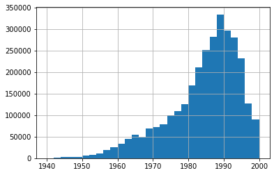

```python
# where to cut high age entries? Distribution of members
bin_edges = np.arange(1940, 2002, 2)
alldata.member_birth_year.hist(bins = bin_edges)

# it is reliable to cut after age of 60, but it would be interesting to look at the behavior of elder people, since nowadays people of higher age were more active and also will become more
# so I decide to leave the tail of elderly people up to 79 y
```

- all over 79 years could be deleted

```python
# looking for missing entries in station columns

missing_stations= alldata[alldata.start_station_id.isna() == True]

missing_stations

#missing_stations.plot(kind='scatter', x= 'start_station_longitude', y='start_station_latitude')


#plt.scatter(data=alldata, x='start_station_longitude', y='start_station_latitude', alpha=0.1);
#plt.scatter(missing_stations, x='start_station_longitude', y='start_station_latitude', color='red')

# coordinates differ from others, delete rows
```

|  | duration_sec | start_time | end_time | start_station_id | start_station_name | start_station_latitude | start_station_longitude | end_station_id | end_station_name | end_station_latitude | end_station_longitude | bike_id | user_type | member_birth_year | member_gender | bike_share_for_all_trip | rental_access_method | Unnamed: 16 |
| --- | --- | --- | --- | --- | --- | --- | --- | --- | --- | --- | --- | --- | --- | --- | --- | --- | --- | --- |
| 623364 | 5572 | 2018-06-30 20:58:31.8550 | 2018-06-30 22:31:24.5930 | NaN | NaN | 37.400000 | -121.940000 | NaN | NaN | 37.400000 | -121.940000 | 4202 | Customer | 1989.0 | Male | No | NaN | NaN |
| 623376 | 573 | 2018-06-30 22:12:27.5110 | 2018-06-30 22:22:01.1740 | NaN | NaN | 37.400000 | -121.940000 | NaN | NaN | 37.400000 | -121.930000 | 4095 | Subscriber | 1994.0 | Male | Yes | NaN | NaN |
| 623393 | 850 | 2018-06-30 22:01:25.5850 | 2018-06-30 22:15:36.1510 | NaN | NaN | 37.410000 | -121.940000 | NaN | NaN | 37.410000 | -121.950000 | 4122 | Customer | 1990.0 | Male | No | NaN | NaN |
| 623429 | 562 | 2018-06-30 21:52:05.1180 | 2018-06-30 22:01:27.4400 | NaN | NaN | 37.410000 | -121.940000 | NaN | NaN | 37.420000 | -121.940000 | 4184 | Subscriber | 1989.0 | Male | No | NaN | NaN |
| 623456 | 819 | 2018-06-30 21:37:34.5060 | 2018-06-30 21:51:13.7290 | NaN | NaN | 37.410000 | -121.940000 | NaN | NaN | 37.410000 | -121.960000 | 4137 | Customer | 1985.0 | Male | No | NaN | NaN |
| 623472 | 1176 | 2018-06-30 21:23:30.4880 | 2018-06-30 21:43:07.3310 | NaN | NaN | 37.410000 | -121.940000 | NaN | NaN | 37.410000 | -121.940000 | 4152 | Customer | 1961.0 | Male | No | NaN | NaN |
| 623479 | 160 | 2018-06-30 21:37:50.9260 | 2018-06-30 21:40:30.9300 | NaN | NaN | 37.410000 | -121.940000 | NaN | NaN | 37.420000 | -121.940000 | 4105 | Subscriber | 1990.0 | Female | No | NaN | NaN |
| 623548 | 7242 | 2018-06-30 19:19:19.5600 | 2018-06-30 21:20:02.1110 | NaN | NaN | 37.400000 | -121.940000 | NaN | NaN | 37.400000 | -121.940000 | 4082 | Customer | 1990.0 | Male | No | NaN | NaN |
| 623549 | 725 | 2018-06-30 21:06:44.3580 | 2018-06-30 21:18:50.2180 | NaN | NaN | 37.410000 | -121.960000 | NaN | NaN | 37.410000 | -121.960000 | 4156 | Customer | 1983.0 | Male | No | NaN | NaN |
| 623550 | 694 | 2018-06-30 21:05:49.6180 | 2018-06-30 21:17:24.2670 | NaN | NaN | 37.400000 | -121.930000 | NaN | NaN | 37.410000 | -121.940000 | 4136 | Customer | 1987.0 | Female | No | NaN | NaN |
| 623551 | 1608 | 2018-06-30 20:50:23.7450 | 2018-06-30 21:17:12.6390 | NaN | NaN | 37.400000 | -121.920000 | NaN | NaN | 37.410000 | -121.940000 | 4184 | Customer | 1986.0 | Male | No | NaN | NaN |
| 623563 | 1444 | 2018-06-30 20:49:04.1980 | 2018-06-30 21:13:08.8980 | NaN | NaN | 37.400000 | -121.940000 | NaN | NaN | 37.400000 | -121.940000 | 4135 | Customer | 1982.0 | Male | No | NaN | NaN |
| 623573 | 3855 | 2018-06-30 20:06:14.4580 | 2018-06-30 21:10:29.5520 | NaN | NaN | 37.400000 | -121.930000 | NaN | NaN | 37.400000 | -121.930000 | 4171 | Customer | 1975.0 | Male | No | NaN | NaN |
| 623581 | 3344 | 2018-06-30 20:12:39.0470 | 2018-06-30 21:08:23.1120 | NaN | NaN | 37.400000 | -121.940000 | NaN | NaN | 37.400000 | -121.940000 | 4110 | Customer | 1988.0 | Female | No | NaN | NaN |
| 623600 | 1700 | 2018-06-30 20:30:05.1760 | 2018-06-30 20:58:25.7960 | NaN | NaN | 37.400000 | -121.940000 | NaN | NaN | 37.400000 | -121.940000 | 4202 | Subscriber | 1984.0 | Male | No | NaN | NaN |
| 623663 | 462 | 2018-06-30 20:31:55.1570 | 2018-06-30 20:39:38.0370 | NaN | NaN | 37.410000 | -121.930000 | NaN | NaN | 37.400000 | -121.920000 | 4132 | Subscriber | NaN | NaN | No | NaN | NaN |
| 623670 | 1320 | 2018-06-30 20:13:48.8020 | 2018-06-30 20:35:49.6220 | NaN | NaN | 37.400000 | -121.920000 | NaN | NaN | 37.400000 | -121.920000 | 4237 | Subscriber | 1988.0 | Male | No | NaN | NaN |
| 623696 | 3780 | 2018-06-30 19:25:16.0000 | 2018-06-30 20:28:16.0730 | NaN | NaN | 37.400000 | -121.940000 | NaN | NaN | 37.400000 | -121.940000 | 4202 | Customer | 1987.0 | Female | No | NaN | NaN |
| 623698 | 328 | 2018-06-30 20:22:16.2300 | 2018-06-30 20:27:44.2720 | NaN | NaN | 37.410000 | -121.940000 | NaN | NaN | 37.410000 | -121.940000 | 4092 | Subscriber | 1989.0 | Male | No | NaN | NaN |
| 623717 | 1737 | 2018-06-30 19:55:39.7310 | 2018-06-30 20:24:36.7880 | NaN | NaN | 37.400000 | -121.940000 | NaN | NaN | 37.410000 | -121.940000 | 4152 | Customer | 1994.0 | Female | No | NaN | NaN |
| 623718 | 1626 | 2018-06-30 19:57:28.9530 | 2018-06-30 20:24:35.4630 | NaN | NaN | 37.400000 | -121.940000 | NaN | NaN | 37.410000 | -121.940000 | 4122 | Customer | 1994.0 | Female | No | NaN | NaN |
| 623751 | 459 | 2018-06-30 20:06:35.7380 | 2018-06-30 20:14:15.3080 | NaN | NaN | 37.420000 | -121.960000 | NaN | NaN | 37.410000 | -121.960000 | 4251 | Subscriber | 1992.0 | Other | No | NaN | NaN |
| 623753 | 1613 | 2018-06-30 19:47:02.0900 | 2018-06-30 20:13:55.7710 | NaN | NaN | 37.410000 | -121.940000 | NaN | NaN | 37.410000 | -121.940000 | 4092 | Customer | 1987.0 | Male | No | NaN | NaN |
| 623800 | 1565 | 2018-06-30 19:34:00.3970 | 2018-06-30 20:00:06.0270 | NaN | NaN | 37.400000 | -121.930000 | NaN | NaN | 37.410000 | -121.940000 | 4137 | Customer | 1988.0 | Male | No | NaN | NaN |
| 623810 | 1768 | 2018-06-30 19:28:06.8040 | 2018-06-30 19:57:35.0220 | NaN | NaN | 37.400000 | -121.940000 | NaN | NaN | 37.400000 | -121.940000 | 4098 | Customer | 1976.0 | Male | No | NaN | NaN |
| 623867 | 2003 | 2018-06-30 19:09:00.7110 | 2018-06-30 19:42:24.6860 | NaN | NaN | 37.400000 | -121.940000 | NaN | NaN | 37.410000 | -121.940000 | 4089 | Customer | 1991.0 | Male | No | NaN | NaN |
| 623870 | 1878 | 2018-06-30 19:10:56.9880 | 2018-06-30 19:42:15.4090 | NaN | NaN | 37.400000 | -121.940000 | NaN | NaN | 37.410000 | -121.940000 | 4092 | Customer | 1989.0 | Male | No | NaN | NaN |
| 623875 | 1655 | 2018-06-30 19:13:57.5160 | 2018-06-30 19:41:33.2480 | NaN | NaN | 37.400000 | -121.940000 | NaN | NaN | 37.400000 | -121.940000 | 4194 | Customer | 1986.0 | Male | No | NaN | NaN |
| 623923 | 1828 | 2018-06-30 19:01:40.2390 | 2018-06-30 19:32:08.2960 | NaN | NaN | 37.410000 | -121.940000 | NaN | NaN | 37.400000 | -121.930000 | 4137 | Customer | 1988.0 | Male | No | NaN | NaN |
| 623925 | 81932 | 2018-06-29 20:46:13.9310 | 2018-06-30 19:31:46.4390 | NaN | NaN | 37.400000 | -121.940000 | NaN | NaN | 37.400000 | -121.940000 | 4232 | Subscriber | 1992.0 | Male | No | NaN | NaN |
| ... | ... | ... | ... | ... | ... | ... | ... | ... | ... | ... | ... | ... | ... | ... | ... | ... | ... | ... |
| 3308402 | 786 | 2019-07-20 12:32:46 | 2019-07-20 12:45:53 | NaN | NaN | 37.884531 | -122.267517 | NaN | NaN | 37.870117 | -122.283802 | 180996 | Subscriber | 1995.0 | F | NaN | NaN | app |
| 3308403 | 294 | 2019-07-20 15:51:15 | 2019-07-20 15:56:09 | NaN | NaN | 37.884533 | -122.267459 | NaN | NaN | 37.878462 | -122.269428 | 127704 | Subscriber | 1995.0 | F | NaN | NaN | app |
| 3308404 | 446 | 2019-07-25 09:34:11 | 2019-07-25 09:41:37 | NaN | NaN | 37.884553 | -122.267466 | 250.0 | North Berkeley BART Station | 37.873558 | -122.283093 | 399523 | Subscriber | 1992.0 | F | NaN | NaN | app |
| 3308405 | 630 | 2019-07-25 18:54:10 | 2019-07-25 19:04:41 | NaN | NaN | 37.884640 | -122.266503 | NaN | NaN | 37.861912 | -122.267290 | 587442 | Customer | NaN | NaN | NaN | NaN | app |
| 3308406 | 381 | 2019-07-23 07:17:37 | 2019-07-23 07:23:58 | NaN | NaN | 37.884649 | -122.266572 | 245.0 | Downtown Berkeley BART | 37.870139 | -122.268422 | 521109 | Subscriber | 1994.0 | M | NaN | NaN | app |
| 3308407 | 343 | 2019-07-22 07:16:22 | 2019-07-22 07:22:06 | NaN | NaN | 37.884652 | -122.266483 | 245.0 | Downtown Berkeley BART | 37.870139 | -122.268422 | 423176 | Subscriber | 1994.0 | M | NaN | NaN | app |
| 3308408 | 853 | 2019-07-25 09:42:18 | 2019-07-25 09:56:31 | NaN | NaN | 37.884667 | -122.266476 | NaN | NaN | 37.865415 | -122.255998 | 489867 | Customer | NaN | NaN | NaN | NaN | app |
| 3308409 | 887 | 2019-07-21 13:36:58 | 2019-07-21 13:51:45 | NaN | NaN | 37.884668 | -122.266512 | 249.0 | Russell St at College Ave | 37.858473 | -122.253253 | 343860 | Subscriber | 1992.0 | F | NaN | NaN | app |
| 3308410 | 349 | 2019-07-20 18:24:28 | 2019-07-20 18:30:18 | NaN | NaN | 37.884675 | -122.266500 | 239.0 | Bancroft Way at Telegraph Ave | 37.868813 | -122.258764 | 343860 | Subscriber | 1974.0 | M | NaN | NaN | app |
| 3308411 | 940 | 2019-07-30 20:03:51 | 2019-07-30 20:19:31 | NaN | NaN | 37.884684 | -122.266478 | 249.0 | Russell St at College Ave | 37.858473 | -122.253253 | 377036 | Subscriber | 1981.0 | F | NaN | NaN | app |
| 3308412 | 630 | 2019-07-29 11:29:06 | 2019-07-29 11:39:37 | NaN | NaN | 37.884697 | -122.266490 | NaN | NaN | 37.874029 | -122.256652 | 402066 | Customer | NaN | NaN | NaN | NaN | app |
| 3308413 | 538 | 2019-07-19 20:26:34 | 2019-07-19 20:35:33 | NaN | NaN | 37.884698 | -122.266505 | NaN | NaN | 37.868436 | -122.262437 | 883574 | Subscriber | 1999.0 | M | NaN | NaN | app |
| 3308414 | 2277 | 2019-07-17 21:47:27 | 2019-07-17 22:25:24 | NaN | NaN | 37.884766 | -122.267647 | NaN | NaN | 37.809895 | -122.231847 | 335587 | Subscriber | 1974.0 | M | NaN | NaN | app |
| 3308415 | 975 | 2019-07-20 12:31:57 | 2019-07-20 12:48:13 | NaN | NaN | 37.884789 | -122.267693 | NaN | NaN | 37.850831 | -122.256290 | 512019 | Subscriber | 1974.0 | M | NaN | NaN | app |
| 3308416 | 392 | 2019-07-27 10:00:41 | 2019-07-27 10:07:14 | NaN | NaN | 37.884926 | -122.269838 | NaN | NaN | 37.873770 | -122.266781 | 392211 | Subscriber | 1995.0 | M | NaN | NaN | clipper |
| 3308417 | 2305 | 2019-07-27 02:15:15 | 2019-07-27 02:53:40 | NaN | NaN | 37.885137 | -122.269871 | NaN | NaN | 37.880477 | -122.274070 | 343860 | Subscriber | 1998.0 | M | NaN | NaN | app |
| 3308418 | 571 | 2019-07-18 17:22:15 | 2019-07-18 17:31:47 | NaN | NaN | 37.885269 | -122.268842 | 245.0 | Downtown Berkeley BART | 37.870139 | -122.268422 | 765740 | Subscriber | 1987.0 | F | NaN | NaN | clipper |
| 3308419 | 1761 | 2019-07-27 15:24:29 | 2019-07-27 15:53:50 | NaN | NaN | 37.885499 | -122.269924 | NaN | NaN | 37.833855 | -122.292240 | 176791 | Subscriber | 2001.0 | M | NaN | NaN | app |
| 3308420 | 435 | 2019-07-15 12:29:03 | 2019-07-15 12:36:19 | NaN | NaN | 37.885526 | -122.270030 | NaN | NaN | 37.875709 | -122.271232 | 498377 | Subscriber | 1974.0 | M | NaN | NaN | app |
| 3308421 | 829 | 2019-07-10 21:16:04 | 2019-07-10 21:29:53 | NaN | NaN | 37.885528 | -122.262463 | NaN | NaN | 37.855544 | -122.263579 | 425554 | Subscriber | 1996.0 | O | NaN | NaN | app |
| 3308422 | 1072 | 2019-07-20 12:42:19 | 2019-07-20 13:00:12 | NaN | NaN | 37.885602 | -122.269899 | NaN | NaN | 37.846520 | -122.252068 | 438085 | Subscriber | 1986.0 | M | NaN | NaN | app |
| 3308423 | 2354 | 2019-07-14 18:31:19 | 2019-07-14 19:10:34 | NaN | NaN | 37.885752 | -122.267697 | 156.0 | Stanford Ave at Hollis St | 37.838443 | -122.288665 | 399523 | Subscriber | 1977.0 | M | NaN | NaN | app |
| 3308424 | 1601 | 2019-07-28 11:30:50 | 2019-07-28 11:57:31 | NaN | NaN | 37.885753 | -122.267630 | NaN | NaN | 37.859788 | -122.286398 | 466175 | Subscriber | 1998.0 | M | NaN | NaN | app |
| 3308425 | 101 | 2019-07-28 15:12:28 | 2019-07-28 15:14:09 | NaN | NaN | 37.885773 | -122.267646 | NaN | NaN | 37.885779 | -122.267741 | 572370 | Customer | NaN | NaN | NaN | NaN | app |
| 3308426 | 630 | 2019-07-25 14:00:17 | 2019-07-25 14:10:48 | NaN | NaN | 37.885792 | -122.267613 | NaN | NaN | 37.868089 | -122.278545 | 353655 | Subscriber | 1992.0 | F | NaN | NaN | app |
| 3308427 | 850 | 2019-07-28 11:02:37 | 2019-07-28 11:16:48 | NaN | NaN | 37.888052 | -122.256561 | NaN | NaN | 37.870571 | -122.266337 | 148227 | Subscriber | 1995.0 | F | NaN | NaN | app |
| 3308428 | 589 | 2019-07-30 09:33:52 | 2019-07-30 09:43:41 | NaN | NaN | 37.888215 | -122.266832 | NaN | NaN | 37.869662 | -122.268208 | 547361 | Subscriber | 1981.0 | M | NaN | NaN | app |
| 3308429 | 370 | 2019-07-26 12:50:49 | 2019-07-26 12:56:59 | NaN | NaN | 37.891297 | -122.279522 | 254.0 | Vine St at Shattuck Ave | 37.880222 | -122.269592 | 896256 | Subscriber | 1964.0 | F | NaN | NaN | clipper |
| 3308430 | 593 | 2019-07-30 20:26:47 | 2019-07-30 20:36:41 | NaN | NaN | 37.892187 | -122.272765 | NaN | NaN | 37.881075 | -122.270206 | 440004 | Subscriber | NaN | ? | NaN | NaN | app |
| 3308431 | 1716 | 2019-07-31 06:55:02 | 2019-07-31 07:23:39 | NaN | NaN | 37.895300 | -122.269339 | 409.0 | 2100 Powell St | 37.839543 | -122.298718 | 512019 | Subscriber | 1983.0 | F | NaN | NaN | app |

33715 rows × 18 columns

```python
# start_station_latitude, end_station_latitude 0

alldata[alldata.start_station_latitude == 0.0]
alldata[alldata.end_station_latitude == 0.0]

# there are entries with coordinates of 0, station called SF Test Station, probably test entries or maybe from positioning bikes to a station?
```

|  | duration_sec | start_time | end_time | start_station_id | start_station_name | start_station_latitude | start_station_longitude | end_station_id | end_station_name | end_station_latitude | end_station_longitude | bike_id | user_type | member_birth_year | member_gender | bike_share_for_all_trip | rental_access_method | Unnamed: 16 |
| --- | --- | --- | --- | --- | --- | --- | --- | --- | --- | --- | --- | --- | --- | --- | --- | --- | --- | --- |
| 2496691 | 2365 | 2019-04-30 18:21:42.6100 | 2019-04-30 19:01:08.1460 | 50.0 | 2nd St at Townsend St | 37.780526 | -122.390288 | 420.0 | SF Test Station | 0.0 | 0.0 | 1612 | Subscriber | 1995.0 | Female | No | NaN | NaN |
| 2497457 | 1964 | 2019-04-30 17:31:19.6460 | 2019-04-30 18:04:04.5180 | 98.0 | Valencia St at 16th St | 37.765052 | -122.421866 | 420.0 | SF Test Station | 0.0 | 0.0 | 3507 | Subscriber | 1981.0 | Female | No | NaN | NaN |
| 2497611 | 546 | 2019-04-30 17:45:38.4520 | 2019-04-30 17:54:45.2580 | 370.0 | Jones St at Post St | 37.787327 | -122.413278 | 420.0 | SF Test Station | 0.0 | 0.0 | 1142 | Subscriber | 1991.0 | Female | Yes | NaN | NaN |
| 2497690 | 630 | 2019-04-30 17:39:33.5070 | 2019-04-30 17:50:04.3140 | 21.0 | Montgomery St BART Station (Market St at 2nd St) | 37.789625 | -122.400811 | 420.0 | SF Test Station | 0.0 | 0.0 | 3500 | Subscriber | 1991.0 | Male | No | NaN | NaN |
| 2498143 | 433 | 2019-04-30 17:17:10.4860 | 2019-04-30 17:24:23.9190 | 11.0 | Davis St at Jackson St | 37.797280 | -122.398436 | 420.0 | SF Test Station | 0.0 | 0.0 | 1181 | Subscriber | 1995.0 | Male | No | NaN | NaN |
| 2498226 | 1233 | 2019-04-30 16:58:41.2090 | 2019-04-30 17:19:14.6890 | 81.0 | Berry St at 4th St | 37.775880 | -122.393170 | 420.0 | SF Test Station | 0.0 | 0.0 | 2535 | Subscriber | 1970.0 | Male | No | NaN | NaN |
| 2498258 | 1306 | 2019-04-30 16:55:35.9240 | 2019-04-30 17:17:22.1620 | 80.0 | Townsend St at 5th St | 37.775235 | -122.397437 | 420.0 | SF Test Station | 0.0 | 0.0 | 462 | Subscriber | 1992.0 | Male | No | NaN | NaN |
| 2498549 | 764 | 2019-04-30 16:44:12.3510 | 2019-04-30 16:56:56.5390 | 16.0 | Steuart St at Market St | 37.794130 | -122.394430 | 420.0 | SF Test Station | 0.0 | 0.0 | 1880 | Customer | 1976.0 | Male | No | NaN | NaN |
| 2510800 | 1491 | 2019-04-28 18:40:41.2880 | 2019-04-28 19:05:33.0630 | 377.0 | Fell St at Stanyan St | 37.771917 | -122.453704 | 420.0 | SF Test Station | 0.0 | 0.0 | 150 | Customer | 1981.0 | Male | No | NaN | NaN |
| 2510853 | 680 | 2019-04-28 18:40:08.3240 | 2019-04-28 18:51:28.3570 | 139.0 | Garfield Square (25th St at Harrison St) | 37.751017 | -122.411901 | 420.0 | SF Test Station | 0.0 | 0.0 | 311 | Subscriber | 1981.0 | Female | No | NaN | NaN |
| 2510968 | 764 | 2019-04-28 18:10:38.1700 | 2019-04-28 18:23:22.4760 | 412.0 | Glen Park BART Station | 37.732813 | -122.434140 | 420.0 | SF Test Station | 0.0 | 0.0 | 333 | Customer | 1989.0 | Male | No | NaN | NaN |
| 2510969 | 904 | 2019-04-28 18:08:13.5760 | 2019-04-28 18:23:18.3670 | 412.0 | Glen Park BART Station | 37.732813 | -122.434140 | 420.0 | SF Test Station | 0.0 | 0.0 | 2760 | Customer | 1989.0 | Male | No | NaN | NaN |
| 2511000 | 1501 | 2019-04-28 17:52:27.3450 | 2019-04-28 18:17:28.4100 | 377.0 | Fell St at Stanyan St | 37.771917 | -122.453704 | 420.0 | SF Test Station | 0.0 | 0.0 | 3632 | Subscriber | 1997.0 | Male | No | NaN | NaN |
| 2511001 | 1503 | 2019-04-28 17:52:22.2100 | 2019-04-28 18:17:25.5450 | 377.0 | Fell St at Stanyan St | 37.771917 | -122.453704 | 420.0 | SF Test Station | 0.0 | 0.0 | 901 | Subscriber | 1995.0 | Male | No | NaN | NaN |
| 2511020 | 840 | 2019-04-28 18:00:23.5670 | 2019-04-28 18:14:23.5990 | 88.0 | 11th St at Bryant St | 37.770030 | -122.411726 | 420.0 | SF Test Station | 0.0 | 0.0 | 536 | Subscriber | 1981.0 | Male | No | NaN | NaN |
| 2536236 | 195 | 2019-04-24 16:53:35.5910 | 2019-04-24 16:56:51.0060 | 104.0 | 4th St at 16th St | 37.767045 | -122.390833 | 420.0 | SF Test Station | 0.0 | 0.0 | 3498 | Subscriber | 1970.0 | Female | No | NaN | NaN |
| 2545133 | 921 | 2019-04-23 13:14:09.4920 | 2019-04-23 13:29:31.3330 | 20.0 | Mechanics Monument Plaza (Market St at Bush St) | 37.791300 | -122.399051 | 420.0 | SF Test Station | 0.0 | 0.0 | 1768 | Subscriber | 1967.0 | Male | No | NaN | NaN |
| 2583334 | 912 | 2019-04-17 09:30:11.7640 | 2019-04-17 09:45:24.2630 | 399.0 | Bay St at Fillmore St | 37.802636 | -122.436289 | 420.0 | SF Test Station | 0.0 | 0.0 | 1939 | Subscriber | 1982.0 | Male | No | NaN | NaN |

- there are non valid entries for stations/coordinates

```python
alldata[alldata.start_station_longitude <= -122.272765]
```

|  | duration_sec | start_time | end_time | start_station_id | start_station_name | start_station_latitude | start_station_longitude | end_station_id | end_station_name | end_station_latitude | end_station_longitude | bike_id | user_type | member_birth_year | member_gender | bike_share_for_all_trip | rental_access_method | Unnamed: 16 |
| --- | --- | --- | --- | --- | --- | --- | --- | --- | --- | --- | --- | --- | --- | --- | --- | --- | --- | --- |
| 0 | 75284 | 2018-01-31 22:52:35.2390 | 2018-02-01 19:47:19.8240 | 120.0 | Mission Dolores Park | 37.761420 | -122.426435 | 285.0 | Webster St at O'Farrell St | 37.783521 | -122.431158 | 2765 | Subscriber | 1986.0 | Male | No | NaN | NaN |
| 1 | 85422 | 2018-01-31 16:13:34.3510 | 2018-02-01 15:57:17.3100 | 15.0 | San Francisco Ferry Building (Harry Bridges Pl... | 37.795392 | -122.394203 | 15.0 | San Francisco Ferry Building (Harry Bridges Pl... | 37.795392 | -122.394203 | 2815 | Customer | NaN | NaN | No | NaN | NaN |
| 3 | 61076 | 2018-01-31 14:53:23.5620 | 2018-02-01 07:51:20.5000 | 75.0 | Market St at Franklin St | 37.773793 | -122.421239 | 47.0 | 4th St at Harrison St | 37.780955 | -122.399749 | 321 | Customer | NaN | NaN | No | NaN | NaN |
| 4 | 39966 | 2018-01-31 19:52:24.6670 | 2018-02-01 06:58:31.0530 | 74.0 | Laguna St at Hayes St | 37.776435 | -122.426244 | 19.0 | Post St at Kearny St | 37.788975 | -122.403452 | 617 | Subscriber | 1991.0 | Male | No | NaN | NaN |
| 5 | 6477 | 2018-01-31 22:58:44.8670 | 2018-02-01 00:46:41.9080 | 236.0 | Market St at 8th St | 37.803686 | -122.282497 | 160.0 | West Oakland BART Station | 37.805318 | -122.294837 | 1306 | Customer | NaN | NaN | No | NaN | NaN |
| 6 | 453 | 2018-01-31 23:53:53.6320 | 2018-02-01 00:01:26.8050 | 110.0 | 17th & Folsom Street Park (17th St at Folsom St) | 37.763708 | -122.415204 | 134.0 | Valencia St at 24th St | 37.752428 | -122.420628 | 3571 | Subscriber | 1988.0 | Male | No | NaN | NaN |
| 7 | 180 | 2018-01-31 23:52:09.9030 | 2018-01-31 23:55:10.8070 | 81.0 | Berry St at 4th St | 37.775880 | -122.393170 | 93.0 | 4th St at Mission Bay Blvd S | 37.770407 | -122.391198 | 1403 | Subscriber | 1980.0 | Male | No | NaN | NaN |
| 8 | 996 | 2018-01-31 23:34:56.0040 | 2018-01-31 23:51:32.6740 | 134.0 | Valencia St at 24th St | 37.752428 | -122.420628 | 4.0 | Cyril Magnin St at Ellis St | 37.785881 | -122.408915 | 3675 | Subscriber | 1987.0 | Male | Yes | NaN | NaN |
| 10 | 1316 | 2018-01-31 23:24:00.4160 | 2018-01-31 23:45:56.8240 | 98.0 | Valencia St at 16th St | 37.765052 | -122.421866 | 4.0 | Cyril Magnin St at Ellis St | 37.785881 | -122.408915 | 1278 | Customer | NaN | NaN | No | NaN | NaN |
| 11 | 432 | 2018-01-31 23:34:26.4840 | 2018-01-31 23:41:39.2970 | 89.0 | Division St at Potrero Ave | 37.769218 | -122.407646 | 43.0 | San Francisco Public Library (Grove St at Hyde... | 37.778768 | -122.415929 | 2928 | Subscriber | 1993.0 | Male | No | NaN | NaN |
| 12 | 601 | 2018-01-31 23:29:46.8320 | 2018-01-31 23:39:48.0000 | 223.0 | 16th St Mission BART Station 2 | 37.764765 | -122.420091 | 86.0 | Market St at Dolores St | 37.769305 | -122.426826 | 3016 | Subscriber | 1957.0 | Male | No | NaN | NaN |
| 15 | 188 | 2018-01-31 23:30:58.1360 | 2018-01-31 23:34:06.3910 | 98.0 | Valencia St at 16th St | 37.765052 | -122.421866 | 76.0 | McCoppin St at Valencia St | 37.771662 | -122.422423 | 2556 | Subscriber | 1964.0 | Female | No | NaN | NaN |
| 16 | 808 | 2018-01-31 23:19:58.6030 | 2018-01-31 23:33:27.5310 | 67.0 | San Francisco Caltrain Station 2 (Townsend St... | 37.776639 | -122.395526 | 98.0 | Valencia St at 16th St | 37.765052 | -122.421866 | 3041 | Subscriber | 1976.0 | Male | Yes | NaN | NaN |
| 17 | 378 | 2018-01-31 23:23:23.0680 | 2018-01-31 23:29:42.0440 | 80.0 | Townsend St at 5th St | 37.775306 | -122.397380 | 78.0 | Folsom St at 9th St | 37.773717 | -122.411647 | 546 | Subscriber | 1995.0 | Female | No | NaN | NaN |
| 23 | 462 | 2018-01-31 23:03:48.9400 | 2018-01-31 23:11:31.0290 | 119.0 | 18th St at Noe St | 37.761047 | -122.432642 | 134.0 | Valencia St at 24th St | 37.752428 | -122.420628 | 1432 | Subscriber | 1971.0 | Male | Yes | NaN | NaN |
| 25 | 880 | 2018-01-31 22:53:41.3020 | 2018-01-31 23:08:21.4430 | 123.0 | Folsom St at 19th St | 37.760594 | -122.414817 | 145.0 | 29th St at Church St | 37.743684 | -122.426806 | 3725 | Subscriber | 1986.0 | Male | No | NaN | NaN |
| 26 | 1210 | 2018-01-31 22:45:37.1250 | 2018-01-31 23:05:47.5760 | 285.0 | Webster St at O'Farrell St | 37.783521 | -122.431158 | 133.0 | Valencia St at 22nd St | 37.755213 | -122.420975 | 1059 | Subscriber | 1991.0 | Male | No | NaN | NaN |
| 28 | 592 | 2018-01-31 22:53:27.7790 | 2018-01-31 23:03:20.2900 | 202.0 | Washington St at 8th St | 37.800754 | -122.274894 | 195.0 | Bay Pl at Vernon St | 37.812314 | -122.260779 | 1834 | Customer | 1978.0 | Male | No | NaN | NaN |
| 29 | 1059 | 2018-01-31 22:45:16.5700 | 2018-01-31 23:02:56.2850 | 141.0 | Valencia St at Cesar Chavez St | 37.747998 | -122.420219 | 79.0 | 7th St at Brannan St | 37.773492 | -122.403673 | 1248 | Subscriber | 1988.0 | Male | No | NaN | NaN |
| 30 | 375 | 2018-01-31 22:56:31.0820 | 2018-01-31 23:02:46.5830 | 15.0 | San Francisco Ferry Building (Harry Bridges Pl... | 37.795392 | -122.394203 | 6.0 | The Embarcadero at Sansome St | 37.804770 | -122.403234 | 3401 | Subscriber | 1988.0 | Male | No | NaN | NaN |
| 31 | 300 | 2018-01-31 22:57:24.0420 | 2018-01-31 23:02:24.2720 | 114.0 | Rhode Island St at 17th St | 37.764478 | -122.402570 | 93.0 | 4th St at Mission Bay Blvd S | 37.770407 | -122.391198 | 3224 | Subscriber | 1981.0 | Male | No | NaN | NaN |
| 32 | 2219 | 2018-01-31 22:24:39.9430 | 2018-01-31 23:01:39.5710 | 30.0 | San Francisco Caltrain (Townsend St at 4th St) | 37.776598 | -122.395282 | 81.0 | Berry St at 4th St | 37.775880 | -122.393170 | 1757 | Subscriber | 1991.0 | Female | No | NaN | NaN |
| 33 | 330 | 2018-01-31 22:55:48.0730 | 2018-01-31 23:01:18.5060 | 99.0 | Folsom St at 15th St | 37.767037 | -122.415443 | 124.0 | 19th St at Florida St | 37.760447 | -122.410807 | 3379 | Subscriber | 1983.0 | Male | No | NaN | NaN |
| 34 | 870 | 2018-01-31 22:45:38.2350 | 2018-01-31 23:00:09.0340 | 285.0 | Webster St at O'Farrell St | 37.783521 | -122.431158 | 106.0 | Sanchez St at 17th St | 37.763242 | -122.430675 | 1503 | Customer | 1990.0 | Female | No | NaN | NaN |
| 36 | 196 | 2018-01-31 22:55:25.4130 | 2018-01-31 22:58:42.1420 | 93.0 | 4th St at Mission Bay Blvd S | 37.770407 | -122.391198 | 81.0 | Berry St at 4th St | 37.775880 | -122.393170 | 1403 | Subscriber | 1980.0 | Male | No | NaN | NaN |
| 37 | 1499 | 2018-01-31 22:33:06.6430 | 2018-01-31 22:58:06.3040 | 44.0 | Civic Center/UN Plaza BART Station (Market St ... | 37.781074 | -122.411738 | 144.0 | Precita Park | 37.747300 | -122.411403 | 2528 | Subscriber | 1970.0 | Female | No | NaN | NaN |
| 38 | 712 | 2018-01-31 22:45:36.9240 | 2018-01-31 22:57:29.3250 | 285.0 | Webster St at O'Farrell St | 37.783521 | -122.431158 | 95.0 | Sanchez St at 15th St | 37.766219 | -122.431060 | 3619 | Subscriber | 1992.0 | Male | No | NaN | NaN |
| 39 | 1305 | 2018-01-31 22:32:18.1260 | 2018-01-31 22:54:03.4990 | 76.0 | McCoppin St at Valencia St | 37.771662 | -122.422423 | 59.0 | S Van Ness Ave at Market St | 37.774814 | -122.418954 | 2421 | Subscriber | 1994.0 | Male | Yes | NaN | NaN |
| 40 | 514 | 2018-01-31 22:43:52.0760 | 2018-01-31 22:52:26.2230 | 230.0 | 14th St at Mandela Pkwy | 37.810743 | -122.291415 | 159.0 | 24th St at Market St | 37.816060 | -122.278244 | 3503 | Subscriber | 1986.0 | Male | No | NaN | NaN |
| 41 | 222 | 2018-01-31 22:44:28.3640 | 2018-01-31 22:48:11.0220 | 58.0 | Market St at 10th St | 37.776619 | -122.417385 | 61.0 | Howard St at 8th St | 37.776513 | -122.411306 | 3483 | Subscriber | 1971.0 | Male | No | NaN | NaN |
| ... | ... | ... | ... | ... | ... | ... | ... | ... | ... | ... | ... | ... | ... | ... | ... | ... | ... | ... |
| 3308215 | 1150 | 2019-07-28 17:26:42 | 2019-07-28 17:45:52 | NaN | NaN | 37.879894 | -122.298283 | NaN | NaN | 37.836984 | -122.292360 | 557828 | Subscriber | 1994.0 | F | NaN | NaN | app |
| 3308217 | 687 | 2019-07-21 10:05:53 | 2019-07-21 10:17:21 | NaN | NaN | 37.880015 | -122.295514 | 250.0 | North Berkeley BART Station | 37.873558 | -122.283093 | 612916 | Subscriber | NaN | ? | NaN | NaN | app |
| 3308219 | 1211 | 2019-07-20 21:55:21 | 2019-07-20 22:15:33 | NaN | NaN | 37.880122 | -122.275056 | NaN | NaN | 37.845606 | -122.285646 | 549670 | Subscriber | 1993.0 | M | NaN | NaN | app |
| 3308318 | 661 | 2019-07-30 08:28:28 | 2019-07-30 08:39:30 | NaN | NaN | 37.880314 | -122.306452 | NaN | NaN | 37.885089 | -122.303351 | 337617 | Customer | NaN | NaN | NaN | NaN | app |
| 3308325 | 1529 | 2019-07-19 15:45:44 | 2019-07-19 16:11:14 | NaN | NaN | 37.880464 | -122.298171 | NaN | NaN | 37.823483 | -122.287063 | 466175 | Subscriber | NaN | ? | NaN | NaN | app |
| 3308326 | 521 | 2019-07-27 02:53:51 | 2019-07-27 03:02:32 | NaN | NaN | 37.880477 | -122.274070 | NaN | NaN | 37.859583 | -122.286877 | 343860 | Subscriber | 1998.0 | M | NaN | NaN | app |
| 3308328 | 3091 | 2019-07-26 13:51:22 | 2019-07-26 14:42:53 | NaN | NaN | 37.880670 | -122.297375 | NaN | NaN | 37.879400 | -122.269123 | 407727 | Subscriber | NaN | ? | NaN | NaN | app |
| 3308335 | 337 | 2019-07-21 10:11:03 | 2019-07-21 10:16:41 | NaN | NaN | 37.881074 | -122.275303 | 245.0 | Downtown Berkeley BART | 37.870139 | -122.268422 | 549670 | Subscriber | 1993.0 | M | NaN | NaN | app |
| 3308340 | 942 | 2019-07-22 14:17:43 | 2019-07-22 14:33:25 | NaN | NaN | 37.881108 | -122.275182 | 248.0 | Telegraph Ave at Ashby Ave | 37.855956 | -122.259795 | 303429 | Subscriber | 1978.0 | M | NaN | NaN | app |
| 3308342 | 920 | 2019-07-21 13:13:57 | 2019-07-21 13:29:18 | NaN | NaN | 37.881306 | -122.274660 | NaN | NaN | 37.862226 | -122.293592 | 549670 | Subscriber | 1993.0 | M | NaN | NaN | app |
| 3308343 | 1168 | 2019-07-21 11:29:08 | 2019-07-21 11:48:36 | NaN | NaN | 37.881318 | -122.289513 | 274.0 | Oregon St at Adeline St | 37.857567 | -122.267558 | 407727 | Subscriber | 1988.0 | F | NaN | NaN | app |
| 3308344 | 1345 | 2019-07-21 11:25:55 | 2019-07-21 11:48:21 | NaN | NaN | 37.881323 | -122.289335 | 274.0 | Oregon St at Adeline St | 37.857567 | -122.267558 | 490619 | Subscriber | 1993.0 | F | NaN | NaN | app |
| 3308345 | 929 | 2019-07-13 18:51:41 | 2019-07-13 19:07:11 | NaN | NaN | 37.881326 | -122.302047 | NaN | NaN | 37.872011 | -122.276250 | 374197 | Subscriber | NaN | ? | NaN | NaN | app |
| 3308346 | 1321 | 2019-07-28 15:01:22 | 2019-07-28 15:23:24 | NaN | NaN | 37.881437 | -122.290775 | NaN | NaN | 37.886568 | -122.315274 | 896256 | Customer | NaN | NaN | NaN | NaN | app |
| 3308347 | 850 | 2019-07-25 14:26:31 | 2019-07-25 14:40:42 | NaN | NaN | 37.881440 | -122.282274 | NaN | NaN | 37.867883 | -122.258521 | 422792 | Customer | NaN | NaN | NaN | NaN | app |
| 3308348 | 2198 | 2019-07-11 20:35:51 | 2019-07-11 21:12:30 | NaN | NaN | 37.881448 | -122.289762 | 160.0 | West Oakland BART Station | 37.805318 | -122.294837 | 613824 | Subscriber | 1984.0 | M | NaN | NaN | clipper |
| 3308349 | 860 | 2019-07-25 14:26:21 | 2019-07-25 14:40:42 | NaN | NaN | 37.881484 | -122.282242 | NaN | NaN | 37.867817 | -122.258498 | 140535 | Subscriber | 1993.0 | F | NaN | NaN | app |
| 3308350 | 1903 | 2019-07-18 19:55:25 | 2019-07-18 20:27:08 | NaN | NaN | 37.881500 | -122.273812 | NaN | NaN | 37.845314 | -122.242263 | 297603 | Subscriber | NaN | ? | NaN | NaN | app |
| 3308351 | 586 | 2019-07-24 19:51:21 | 2019-07-24 20:01:08 | NaN | NaN | 37.881506 | -122.312284 | NaN | NaN | 37.874540 | -122.295191 | 391113 | Subscriber | 2001.0 | M | NaN | NaN | app |
| 3308356 | 1230 | 2019-07-22 21:44:49 | 2019-07-22 22:05:19 | NaN | NaN | 37.881850 | -122.281485 | NaN | NaN | 37.877028 | -122.288041 | 498377 | Customer | NaN | NaN | NaN | NaN | app |
| 3308357 | 692 | 2019-07-24 08:13:04 | 2019-07-24 08:24:36 | NaN | NaN | 37.881978 | -122.283634 | 258.0 | University Ave at Oxford St | 37.872355 | -122.266447 | 391765 | Customer | NaN | NaN | NaN | NaN | app |
| 3308365 | 1539 | 2019-07-16 15:50:26 | 2019-07-16 16:16:05 | NaN | NaN | 37.882097 | -122.296199 | NaN | NaN | 37.850227 | -122.253050 | 707446 | Subscriber | 1981.0 | M | NaN | NaN | app |
| 3308368 | 568 | 2019-07-24 21:09:10 | 2019-07-24 21:18:38 | NaN | NaN | 37.882522 | -122.296741 | NaN | NaN | 37.859790 | -122.286391 | 863041 | Customer | NaN | NaN | NaN | NaN | app |
| 3308369 | 2053 | 2019-07-24 21:10:31 | 2019-07-24 21:44:45 | NaN | NaN | 37.882537 | -122.296730 | NaN | NaN | 37.852513 | -122.276650 | 391113 | Subscriber | 2001.0 | M | NaN | NaN | app |
| 3308379 | 537 | 2019-07-26 18:19:35 | 2019-07-26 18:28:33 | NaN | NaN | 37.883083 | -122.274233 | 250.0 | North Berkeley BART Station | 37.873558 | -122.283093 | 190302 | Customer | NaN | NaN | NaN | NaN | app |
| 3308380 | 1820 | 2019-07-31 06:44:51 | 2019-07-31 07:15:12 | NaN | NaN | 37.883245 | -122.274458 | NaN | NaN | 37.837278 | -122.250127 | 241838 | Subscriber | 2000.0 | M | NaN | NaN | app |
| 3308382 | 344 | 2019-07-26 00:17:32 | 2019-07-26 00:23:16 | NaN | NaN | 37.883291 | -122.273446 | 238.0 | MLK Jr Way at University Ave | 37.871719 | -122.273068 | 312648 | Subscriber | 1994.0 | M | NaN | NaN | app |
| 3308391 | 423 | 2019-07-28 21:36:00 | 2019-07-28 21:43:03 | NaN | NaN | 37.884165 | -122.281342 | NaN | NaN | 37.874270 | -122.292764 | 127704 | Customer | NaN | NaN | NaN | NaN | app |
| 3308392 | 4387 | 2019-07-28 11:39:01 | 2019-07-28 12:52:09 | NaN | NaN | 37.884191 | -122.281265 | NaN | NaN | 37.884192 | -122.281348 | 127704 | Subscriber | NaN | ? | NaN | NaN | app |
| 3308429 | 370 | 2019-07-26 12:50:49 | 2019-07-26 12:56:59 | NaN | NaN | 37.891297 | -122.279522 | 254.0 | Vine St at Shattuck Ave | 37.880222 | -122.269592 | 896256 | Subscriber | 1964.0 | F | NaN | NaN | clipper |

2563164 rows × 18 columns

```python
alldata.start_time.min()
```

```
'2018-01-01 00:01:53.8470'
```

```python
alldata.start_time.max()
```

```
'2019-07-31 23:59:10.6960'
```

Summarizing issues to wrangle about:

Quality issues:

- not needed columns could be dropped
- rows with missing/not valid values in station columns and coordinates
- rows with member_birth_year before 1940, member_birthyear could be transformed to age
- several values for same gender
- start and end time should be of datetime format
- ids should be strings
- for start and end station could be calculated distance
- missing values in bike_share_for_all_trip

# Cleaning

```python
# copy dataframe for cleaning
data_clean = alldata.copy()
```

```python
# drop not needed columns rental_access_method, Unnamed: 16
to_drop = ['rental_access_method', 'Unnamed: 16']
data_clean.drop(to_drop, axis=1, inplace=True)
```

```python
# remove rows with missing station ids
data_clean.dropna(subset=['start_station_id'], inplace=True)
data_clean.dropna(subset=['end_station_id'], inplace=True)
data_clean.info()
# no missing values in station columns anymore
```

```
<class 'pandas.core.frame.DataFrame'>
Int64Index: 3269271 entries, 0 to 3308315
Data columns (total 16 columns):
duration_sec               3269271 non-null int64
start_time                 3269271 non-null object
end_time                   3269271 non-null object
start_station_id           3269271 non-null float64
start_station_name         3269271 non-null object
start_station_latitude     3269271 non-null float64
start_station_longitude    3269271 non-null float64
end_station_id             3269271 non-null float64
end_station_name           3269271 non-null object
end_station_latitude       3269271 non-null float64
end_station_longitude      3269271 non-null float64
bike_id                    3269271 non-null int64
user_type                  3269271 non-null object
member_birth_year          3063983 non-null float64
member_gender              3064806 non-null object
bike_share_for_all_trip    3262399 non-null object
dtypes: float64(7), int64(2), object(7)
memory usage: 424.0+ MB
```

```python
# removing rows with zero values in start and endstation coordinates
startzerovalues = data_clean[data_clean.start_station_latitude == 0.0]
data_clean.drop(startzerovalues.index, inplace=True)
endzerovalues = data_clean[data_clean.end_station_latitude == 0.0]
data_clean.drop(endzerovalues.index, inplace=True)
```

```python
# check if they are gone
data_clean[(data_clean.start_station_latitude == 0.0) | (data_clean.end_station_latitude == 0.0)]
```

|  | duration_sec | start_time | end_time | start_station_id | start_station_name | start_station_latitude | start_station_longitude | end_station_id | end_station_name | end_station_latitude | end_station_longitude | bike_id | user_type | member_birth_year | member_gender | bike_share_for_all_trip |
| --- | --- | --- | --- | --- | --- | --- | --- | --- | --- | --- | --- | --- | --- | --- | --- | --- |

```python
# calculating member age

def calc_age(time, birth_year):
    if time[:4] == '2018':
        return 2018 - birth_year
    else:
        return 2019 - birth_year



data_clean['member_age'] = data_clean.apply(lambda x: calc_age(x['start_time'], x['member_birth_year']), axis=1)

# https://stackoverflow.com/questions/34279378/python-pandas-apply-function-with-two-arguments-to-columns
```

```python
data_clean.sample(10)
```

[output not shown]

```python
# only keeping data with age < 80
data_clean = data_clean[data_clean.member_age < 80]
```

```python
# drop member_birth_year column
data_clean.drop('member_birth_year', axis=1, inplace=True)
```

```python
data_clean.member_age.min(), data_clean.member_age.max(), data_clean.shape
```

```
(18.0, 79.0, (3060012, 16))
```

```python
data_clean.bike_share_for_all_trip.isnull().sum()
```

```
5830
```

```python
# filling missing values in bike_share_for_all_trip with 'Unknown'
data_clean.bike_share_for_all_trip = data_clean.bike_share_for_all_trip.fillna('Unknown')

data_clean.bike_share_for_all_trip.value_counts()
```

```
No         2780294
Yes         273888
Unknown       5830
Name: bike_share_for_all_trip, dtype: int64
```

```python
# values for gender
data_clean.member_gender.value_counts()
```

```
Male      2254121
Female     748951
Other       51110
M            4538
F            1202
O              90
Name: member_gender, dtype: int64
```

```python
# correct gender values
data_clean.member_gender = data_clean.member_gender.apply(lambda x: 'Male' if x=='M' else x)
data_clean.member_gender = data_clean.member_gender.apply(lambda x: 'Female' if x=='F' else x)
data_clean.member_gender = data_clean.member_gender.apply(lambda x: 'Other' if x=='O' else x)

#test
data_clean.member_gender.value_counts()
```

```
Male      2258659
Female     750153
Other       51200
Name: member_gender, dtype: int64
```

```python
# calculating distance between stations
# https://stackoverflow.com/questions/19412462/getting-distance-between-two-points-based-on-latitude-longitude
import geopy
from geopy.distance import geodesic

def get_distance(start_lat, start_long, end_lat, end_long):

    origin = (start_lat, start_long)  # (latitude, longitude) don't confuse
    dist = (end_lat, end_long)
    return geodesic(origin, dist).kilometers

data_clean['distance_km'] = data_clean.apply(lambda x: get_distance(x['start_station_latitude'], x['start_station_longitude'], x['end_station_latitude'], x['end_station_longitude']), axis=1)
```

```python
data_clean.head()
```

|  | duration_sec | start_time | end_time | start_station_id | start_station_name | start_station_latitude | start_station_longitude | end_station_id | end_station_name | end_station_latitude | end_station_longitude | bike_id | user_type | member_gender | bike_share_for_all_trip | member_age | distance_km |
| --- | --- | --- | --- | --- | --- | --- | --- | --- | --- | --- | --- | --- | --- | --- | --- | --- | --- |
| 0 | 75284 | 2018-01-31 22:52:35.2390 | 2018-02-01 19:47:19.8240 | 120.0 | Mission Dolores Park | 37.761420 | -122.426435 | 285.0 | Webster St at O'Farrell St | 37.783521 | -122.431158 | 2765 | Subscriber | Male | No | 32.0 | 2.488001 |
| 2 | 71576 | 2018-01-31 14:23:55.8890 | 2018-02-01 10:16:52.1160 | 304.0 | Jackson St at 5th St | 37.348759 | -121.894798 | 296.0 | 5th St at Virginia St | 37.325998 | -121.877120 | 3039 | Customer | Male | No | 22.0 | 2.972357 |
| 4 | 39966 | 2018-01-31 19:52:24.6670 | 2018-02-01 06:58:31.0530 | 74.0 | Laguna St at Hayes St | 37.776435 | -122.426244 | 19.0 | Post St at Kearny St | 37.788975 | -122.403452 | 617 | Subscriber | Male | No | 27.0 | 2.443038 |
| 6 | 453 | 2018-01-31 23:53:53.6320 | 2018-02-01 00:01:26.8050 | 110.0 | 17th & Folsom Street Park (17th St at Folsom St) | 37.763708 | -122.415204 | 134.0 | Valencia St at 24th St | 37.752428 | -122.420628 | 3571 | Subscriber | Male | No | 30.0 | 1.340181 |
| 7 | 180 | 2018-01-31 23:52:09.9030 | 2018-01-31 23:55:10.8070 | 81.0 | Berry St at 4th St | 37.775880 | -122.393170 | 93.0 | 4th St at Mission Bay Blvd S | 37.770407 | -122.391198 | 1403 | Subscriber | Male | No | 38.0 | 0.631765 |

```python
data_clean.distance_km.describe()
```

```
count    3.060012e+06
mean     1.638947e+00
std      1.049490e+00
min      0.000000e+00
25%      8.860471e-01
50%      1.403524e+00
75%      2.144628e+00
max      6.946598e+01
Name: distance_km, dtype: float64
```

```python
# there are long distances, check for validity
data_clean[data_clean.distance_km >50]
# seem to be valid
```

|  | duration_sec | start_time | end_time | start_station_id | start_station_name | start_station_latitude | start_station_longitude | end_station_id | end_station_name | end_station_latitude | end_station_longitude | bike_id | user_type | member_gender | bike_share_for_all_trip | member_age | distance_km |
| --- | --- | --- | --- | --- | --- | --- | --- | --- | --- | --- | --- | --- | --- | --- | --- | --- | --- |
| 209420 | 21836 | 2018-03-29 14:25:47.6700 | 2018-03-29 20:29:44.2840 | 16.0 | Steuart St at Market St | 37.794130 | -122.394430 | 303.0 | San Pedro St at Hedding St | 37.352601 | -121.905733 | 319 | Customer | Female | No | 44.0 | 65.308125 |
| 1964791 | 7344 | 2019-01-18 11:36:51.4050 | 2019-01-18 13:39:15.4640 | 163.0 | Lake Merritt BART Station | 37.797320 | -122.265320 | 280.0 | San Fernando St at 7th St | 37.337122 | -121.883215 | 5413 | Subscriber | Male | No | 34.0 | 61.223848 |
| 2167841 | 6945 | 2019-02-12 14:28:44.4020 | 2019-02-12 16:24:30.1580 | 21.0 | Montgomery St BART Station (Market St at 2nd St) | 37.789625 | -122.400811 | 300.0 | Palm St at Willow St | 37.317298 | -121.884995 | 4780 | Subscriber | Female | No | 34.0 | 69.465977 |

#### Saving the cleaned dataframe for further use

```python
# rearrange columns and sorting for start_time before saving:
data = data_clean.copy()
data = data[['start_time', 'end_time', 'start_station_id',
       'start_station_name', 'start_station_latitude',
       'start_station_longitude', 'end_station_id', 'end_station_name',
       'end_station_latitude', 'end_station_longitude', 'bike_id', 'duration_sec',
       'distance_km', 'member_age', 'member_gender', 'user_type','bike_share_for_all_trip'
       ]]
data.sort_values('start_time', inplace=True)
data.head()
```

|  | start_time | end_time | start_station_id | start_station_name | start_station_latitude | start_station_longitude | end_station_id | end_station_name | end_station_latitude | end_station_longitude | bike_id | duration_sec | distance_km | member_age | member_gender | user_type | bike_share_for_all_trip |
| --- | --- | --- | --- | --- | --- | --- | --- | --- | --- | --- | --- | --- | --- | --- | --- | --- | --- |
| 94801 | 2018-01-01 00:07:41.0400 | 2018-01-01 00:10:06.2410 | 316.0 | San Salvador St at 1st St | 37.330165 | -121.885831 | 311.0 | Paseo De San Antonio at 2nd St | 37.333798 | -121.886943 | 2473 | 145 | 0.415073 | 61.0 | Male | Subscriber | No |
| 94800 | 2018-01-01 00:07:52.9430 | 2018-01-01 00:19:47.0750 | 74.0 | Laguna St at Hayes St | 37.776435 | -122.426244 | 70.0 | Central Ave at Fell St | 37.773311 | -122.444293 | 2423 | 714 | 1.627451 | 32.0 | Male | Subscriber | No |
| 94799 | 2018-01-01 00:09:31.7450 | 2018-01-01 00:28:43.1590 | 97.0 | 14th St at Mission St | 37.768265 | -122.420110 | 125.0 | 20th St at Bryant St | 37.759200 | -122.409851 | 3455 | 1151 | 1.352513 | 26.0 | Male | Subscriber | No |
| 94793 | 2018-01-01 00:14:37.1870 | 2018-01-01 00:37:16.4450 | 11.0 | Davis St at Jackson St | 37.797280 | -122.398436 | 323.0 | Broadway at Kearny | 37.798014 | -122.405950 | 2173 | 1359 | 0.666811 | 23.0 | Male | Customer | No |
| 94770 | 2018-01-01 00:15:33.3690 | 2018-01-01 00:58:56.5220 | 17.0 | Embarcadero BART Station (Beale St at Market St) | 37.792251 | -122.397086 | 8.0 | The Embarcadero at Vallejo St | 37.799953 | -122.398525 | 1788 | 2603 | 0.864209 | 24.0 | Male | Subscriber | Yes |

```python
# save cleaned dataframe to csv for further use
data.to_csv('baywheels_data.csv', index=False)
```

# Exploration

```python
# read in cleaned data
data = pd.read_csv('baywheels_data.csv')
```

```python
data.shape
```

```
(3060012, 17)
```

```python
data.info()
```

```
<class 'pandas.core.frame.DataFrame'>
RangeIndex: 3060012 entries, 0 to 3060011
Data columns (total 17 columns):
start_time                 object
end_time                   object
start_station_id           float64
start_station_name         object
start_station_latitude     float64
start_station_longitude    float64
end_station_id             float64
end_station_name           object
end_station_latitude       float64
end_station_longitude      float64
bike_id                    int64
duration_sec               int64
distance_km                float64
member_age                 float64
member_gender              object
user_type                  object
bike_share_for_all_trip    object
dtypes: float64(8), int64(2), object(7)
memory usage: 396.9+ MB
```

```python
# first rename bike_share_for_all_trip to bike_share
data.rename(columns={'bike_share_for_all_trip':'bike_share'}, inplace=True)
```

```python
# adressing datatypes

# setting as categories
to_category = ['user_type', 'member_gender', 'bike_share']
for column in to_category:
    data[column] = data[column].astype('category')

# setting datetime format
data.start_time = pd.to_datetime(data.start_time)
data.end_time = pd.to_datetime(data.end_time)

# setting ids as strings
to_object = ['start_station_id', 'end_station_id', 'bike_id']
for column in to_object:
    data[column] = data[column].astype('int')
    data[column] = data[column].astype('str')

data.info()
```

```
<class 'pandas.core.frame.DataFrame'>
RangeIndex: 3060012 entries, 0 to 3060011
Data columns (total 17 columns):
start_time                 datetime64[ns]
end_time                   datetime64[ns]
start_station_id           object
start_station_name         object
start_station_latitude     float64
start_station_longitude    float64
end_station_id             object
end_station_name           object
end_station_latitude       float64
end_station_longitude      float64
bike_id                    object
duration_sec               int64
distance_km                float64
member_age                 float64
member_gender              category
user_type                  category
bike_share                 category
dtypes: category(3), datetime64[ns](2), float64(6), int64(1), object(5)
memory usage: 335.6+ MB
```

```python
data.describe()
```

|  | start_station_latitude | start_station_longitude | end_station_latitude | end_station_longitude | duration_sec | distance_km | member_age |
| --- | --- | --- | --- | --- | --- | --- | --- |
| count | 3.060012e+06 | 3.060012e+06 | 3.060012e+06 | 3.060012e+06 | 3.060012e+06 | 3.060012e+06 | 3.060012e+06 |
| mean | 3.776926e+01 | -1.223518e+02 | 3.776938e+01 | -1.223513e+02 | 7.614419e+02 | 1.638947e+00 | 3.457622e+01 |
| std | 1.011910e-01 | 1.187812e-01 | 1.010585e-01 | 1.182285e-01 | 1.832583e+03 | 1.049490e+00 | 1.004306e+01 |
| min | 3.726331e+01 | -1.224737e+02 | 3.726331e+01 | -1.224737e+02 | 6.000000e+01 | 0.000000e+00 | 1.800000e+01 |
| 25% | 3.777041e+01 | -1.224117e+02 | 3.777106e+01 | -1.224108e+02 | 3.430000e+02 | 8.860471e-01 | 2.700000e+01 |
| 50% | 3.778101e+01 | -1.223974e+02 | 3.778107e+01 | -1.223971e+02 | 5.430000e+02 | 1.403524e+00 | 3.200000e+01 |
| 75% | 3.779728e+01 | -1.222887e+02 | 3.779728e+01 | -1.222902e+02 | 8.410000e+02 | 2.144628e+00 | 4.000000e+01 |
| max | 3.788022e+01 | -1.218333e+02 | 3.788022e+01 | -1.218333e+02 | 8.628100e+04 | 6.946598e+01 | 7.900000e+01 |

```python
data.head()
```

|  | start_time | end_time | start_station_id | start_station_name | start_station_latitude | start_station_longitude | end_station_id | end_station_name | end_station_latitude | end_station_longitude | bike_id | duration_sec | distance_km | member_age | member_gender | user_type | bike_share |
| --- | --- | --- | --- | --- | --- | --- | --- | --- | --- | --- | --- | --- | --- | --- | --- | --- | --- |
| 0 | 2018-01-01 00:07:41.040 | 2018-01-01 00:10:06.241 | 316 | San Salvador St at 1st St | 37.330165 | -121.885831 | 311 | Paseo De San Antonio at 2nd St | 37.333798 | -121.886943 | 2473 | 145 | 0.415073 | 61.0 | Male | Subscriber | No |
| 1 | 2018-01-01 00:07:52.943 | 2018-01-01 00:19:47.075 | 74 | Laguna St at Hayes St | 37.776435 | -122.426244 | 70 | Central Ave at Fell St | 37.773311 | -122.444293 | 2423 | 714 | 1.627451 | 32.0 | Male | Subscriber | No |
| 2 | 2018-01-01 00:09:31.745 | 2018-01-01 00:28:43.159 | 97 | 14th St at Mission St | 37.768265 | -122.420110 | 125 | 20th St at Bryant St | 37.759200 | -122.409851 | 3455 | 1151 | 1.352513 | 26.0 | Male | Subscriber | No |
| 3 | 2018-01-01 00:14:37.187 | 2018-01-01 00:37:16.445 | 11 | Davis St at Jackson St | 37.797280 | -122.398436 | 323 | Broadway at Kearny | 37.798014 | -122.405950 | 2173 | 1359 | 0.666811 | 23.0 | Male | Customer | No |
| 4 | 2018-01-01 00:15:33.369 | 2018-01-01 00:58:56.522 | 17 | Embarcadero BART Station (Beale St at Market St) | 37.792251 | -122.397086 | 8 | The Embarcadero at Vallejo St | 37.799953 | -122.398525 | 1788 | 2603 | 0.864209 | 24.0 | Male | Subscriber | Yes |

### What is/are the main feature(s) of interest in your dataset?

> For the first exploration steps I had no special intentions, just wanted to look on several variables to get aquainted with the data. But it will be interesting to see when these bikes were used and who uses them.

### What features in the dataset do you think will help support your investigation into your feature(s) of interest?

> Especially data of start and end times as well as user data will be helpful

## Univariate Exploration

> In this section, investigate distributions of individual variables. If you see unusual points or outliers, take a deeper look to clean things up and prepare yourself to look at relationships between variables.

```python
# setting up  color schemes
base_color = sns.color_palette()[0]
base_palette = 'GnBu_d'
```

### Distribution of stations

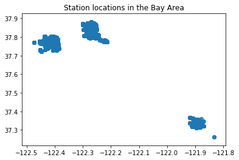

```python
# plotting the coordinates of the stations
plt.scatter(data=data, x='start_station_longitude', y='start_station_latitude', alpha=0.1);
plt.title('Station locations in the Bay Area');
```

There can be seen 3 clusters of stations, that can be identified as San Francisco, San Jose and East Bay.

```python
# setting regions as new variables because they are more handy than coordinates
def region(long):
    if long > -122:
        return('San Jose')
    elif long > -122.35:
        return('East Bay')
    else:
        return('San Francisco')

data['start_region'] = data.start_station_longitude.apply(lambda x: region(x))
data['end_region'] = data.end_station_longitude.apply(lambda x: region(x))
```

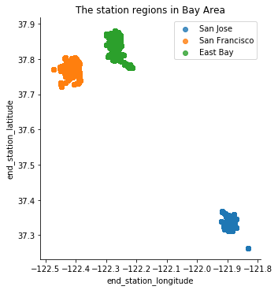

```python
# test if all coordinates are adressed to the right region

sns.lmplot( x="end_station_longitude", y="end_station_latitude", data=data, fit_reg=False, hue='end_region', legend=False);
plt.title('The station regions in Bay Area');
plt.legend();
```

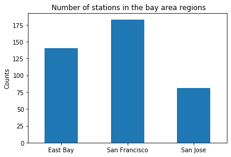

```python
#  number of stations in each region
data.groupby('start_region')['start_station_name'].nunique().plot(kind='bar');
plt.title(' Number of stations in the bay area regions');
plt.ylabel('Counts');
plt.xticks(rotation=0)
plt.xlabel('');
```

> In San Francisco are the most stations, the least in San Jose

#### Is there much traffic between the regions?

```python
long_trips = data[data.start_region != data.end_region]
```

```python
long_trips.groupby(['start_region', 'end_region'])['distance_km'].count()
```

```
start_region   end_region
East Bay       San Francisco    91
               San Jose          1
San Francisco  East Bay         24
               San Jose          2
Name: distance_km, dtype: int64
```

> There are very few riding tours between the regions, most are within the respective region.

### Over which distance the bikes are moved?

Considering the distances between start and end stations. This doesn't give the true distance of bike trips.

```python
# distance
data.distance_km.describe()
```

```
count    3.060012e+06
mean     1.638947e+00
std      1.049490e+00
min      0.000000e+00
25%      8.860471e-01
50%      1.403524e+00
75%      2.144628e+00
max      6.946598e+01
Name: distance_km, dtype: float64
```

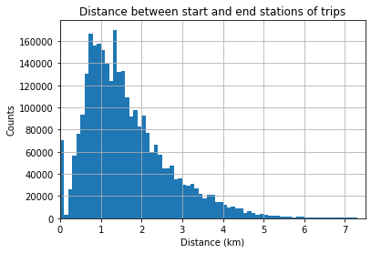

```python
# distance distribution
bin_edges = np.arange(0, data.distance_km.max()+0.1, 0.1)
data.distance_km.hist(bins=bin_edges);
plt.xlim(0, 7.5); #limiting x-axes because of heavily right skewed distribution
plt.title('Distance between start and end stations of trips');
plt.xlabel('Distance (km)');
plt.ylabel('Counts');
```

> The distribution is right skewed, for better view the x-Axis was limited.The most bike movements are within a 2 km region. Interestingly, there is a considerable amount of trips, where start and end station are the same.

## Trip durations

> Trip durations may give better informations about trips, although there is not taken account that there will also be time the bikes are not moved.

> Trip durations are given in seconds, to make them more handy I changed them to minutes

```python
# calculate minutes
data.duration_sec = data.duration_sec.apply(lambda x: x/60)
#rename column
data.rename(columns = {'duration_sec':'duration_min'}, inplace=True)
#control
data.head(2)
```

|  | start_time | end_time | start_station_id | start_station_name | start_station_latitude | start_station_longitude | end_station_id | end_station_name | end_station_latitude | end_station_longitude | bike_id | duration_min | distance_km | member_age | member_gender | user_type | bike_share | start_region | end_region |
| --- | --- | --- | --- | --- | --- | --- | --- | --- | --- | --- | --- | --- | --- | --- | --- | --- | --- | --- | --- |
| 0 | 2018-01-01 00:07:41.040 | 2018-01-01 00:10:06.241 | 316 | San Salvador St at 1st St | 37.330165 | -121.885831 | 311 | Paseo De San Antonio at 2nd St | 37.333798 | -121.886943 | 2473 | 2.416667 | 0.415073 | 61.0 | Male | Subscriber | No | San Jose | San Jose |
| 1 | 2018-01-01 00:07:52.943 | 2018-01-01 00:19:47.075 | 74 | Laguna St at Hayes St | 37.776435 | -122.426244 | 70 | Central Ave at Fell St | 37.773311 | -122.444293 | 2423 | 11.900000 | 1.627451 | 32.0 | Male | Subscriber | No | San Francisco | San Francisco |

```python
# trip duration
data.duration_min.describe()
```

```
count    3.060012e+06
mean     1.269070e+01
std      3.054304e+01
min      1.000000e+00
25%      5.716667e+00
50%      9.050000e+00
75%      1.401667e+01
max      1.438017e+03
Name: duration_min, dtype: float64
```

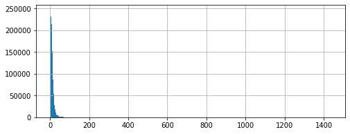

```python
plt.figure(figsize = [8, 3])
bin_edges = np.arange(0,data.duration_min.max()+1, 1 )
data.duration_min.hist(bins=bin_edges);
# better set x-axis
#plt.xlim(0, 150);
#plt.title('Trips with duration up to 1 h');
```

The distribution of trip durations also is right skewed, therefore a logarithmic scale is applied:

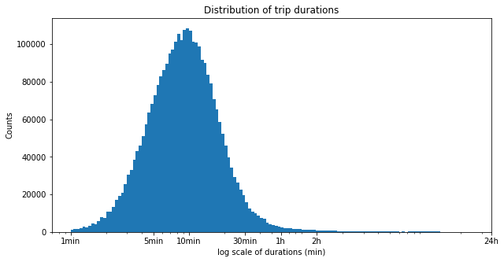

```python
# trying logarithmic scale
plt.figure(figsize = [10, 5])

bin_edges = 10** np.arange(0.001,np.log10(data.duration_min.max())+0.025, 0.025 )

plt.hist(data = data, x='duration_min', bins=bin_edges)
plt.xscale('log');
xtick_locs = [1, 5, 10, 30, 60, 120, 3600]
plt.xticks(xtick_locs, ['1min', '5min', '10min', '30min', '1h', '2h', '24h']);
plt.title('Distribution of trip durations');
plt.xlabel('log scale of durations (min)');
plt.ylabel('Counts');
```

```python
# looking for durations of more than 20 hours
data[data.duration_min > 1200].shape[0]
```

```
384
```

The shortest trip duration is one minute, maximum is around 10 min, the most trips are within 45 min. But there are also some few users keeping the bike between 20 and 24 hours.

#### Looking on duration of trips with distance = 0

> as seen above there are many trips starting and ending at the same station.

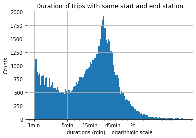

```python
null_distance = data[data.distance_km == 0]

bin_edges = 10** np.arange(0.001,np.log10(null_distance.duration_min.max())+0.025, 0.025 )
null_distance.duration_min.hist(bins=bin_edges);
plt.xscale('log')
xtick_locs = [1, 5, 15, 45, 120]
plt.xticks(xtick_locs, ['1min', '5min', '15min', '45min', '2h']);
plt.title('Duration of trips with same start and end station');
plt.xlabel('durations (min) - logarithmic scale');
plt.ylabel('Counts');
```

> This looks quite strange, there are a lot of very short trips, maybe people just trying out a bike and putting it back?

## Time data

> The dataset consists of data from January 2018 to July 2019. It would be of interest to see if the bike usage changed over time. to examin this further, I extended the dataset by extracting informations from the start_time variable.

```python
# creating some new variables for the datetime data, considering start_time only
data['year_month'] = data.start_time.apply(lambda x: x.strftime('%Y-%m'))
data['weekday'] = data.start_time.dt.weekday_name
data['hour'] = data.start_time.dt.hour

# setting up weekdays as orderd category
weekdays = ["Monday", "Tuesday", "Wednesday", "Thursday", "Friday", "Saturday", "Sunday"]
data.weekday = pd.Categorical(data.weekday, categories = weekdays)

# https://stackoverflow.com/questions/25146121/extracting-just-month-and-year-separately-from-pandas-datetime-column
```

```python
data.sample(5)
#control
```

|  | start_time | end_time | start_station_id | start_station_name | start_station_latitude | start_station_longitude | end_station_id | end_station_name | end_station_latitude | end_station_longitude | ... | distance_km | member_age | member_gender | user_type | bike_share | start_region | end_region | year_month | weekday | hour |
| --- | --- | --- | --- | --- | --- | --- | --- | --- | --- | --- | --- | --- | --- | --- | --- | --- | --- | --- | --- | --- | --- |
| 2110543 | 2019-03-03 18:48:22.745 | 2019-03-03 18:58:52.182 | 350 | 8th St at Brannan St | 37.771431 | -122.405787 | 122 | 19th St at Mission St | 37.760299 | -122.418892 | ... | 1.691175 | 26.0 | Other | Subscriber | No | San Francisco | San Francisco | 2019-03 | Sunday | 18 |
| 888165 | 2018-07-23 16:44:53.524 | 2018-07-23 16:58:08.271 | 104 | 4th St at 16th St | 37.767045 | -122.390833 | 27 | Beale St at Harrison St | 37.788059 | -122.391865 | ... | 2.334240 | 37.0 | Female | Subscriber | No | San Francisco | San Francisco | 2018-07 | Monday | 16 |
| 1512867 | 2018-11-06 05:41:29.529 | 2018-11-06 05:53:05.426 | 305 | Ryland Park | 37.342725 | -121.895617 | 317 | San Salvador St at 9th St | 37.333955 | -121.877349 | ... | 1.888912 | 22.0 | Male | Subscriber | Yes | San Jose | San Jose | 2018-11 | Tuesday | 5 |
| 1326931 | 2018-10-05 17:05:31.538 | 2018-10-05 17:21:57.577 | 363 | Salesforce Transit Center (Natoma St at 2nd St) | 37.787492 | -122.398285 | 76 | McCoppin St at Valencia St | 37.771662 | -122.422423 | ... | 2.758414 | 25.0 | Male | Subscriber | No | San Francisco | San Francisco | 2018-10 | Friday | 17 |
| 422656 | 2018-05-03 08:47:05.154 | 2018-05-03 09:01:05.037 | 56 | Koshland Park | 37.773414 | -122.427317 | 66 | 3rd St at Townsend St | 37.778742 | -122.392741 | ... | 3.102978 | 24.0 | Male | Subscriber | No | San Francisco | San Francisco | 2018-05 | Thursday | 8 |

5 rows × 22 columns

### Time course of trip counts

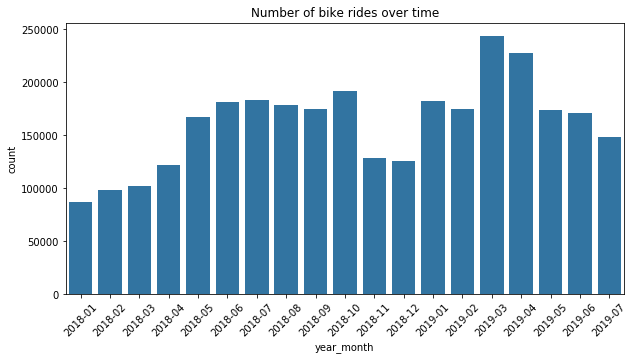

```python
# usage over time
plt.figure(figsize=[10,5]);
sns.countplot(data = data, x = 'year_month', color = base_color);
plt.xticks(rotation=45);
plt.title('Number of bike rides over time');
```

- We can see seasonal changes, in winter months there are fewer rides.
- over all, we can see an increase from 2018 to the beginning of 2019
- there is an increasing step from March to April 2018, possibly due to the introduction of ebikes in April 2018.
- There is a drop after April 2019. In that month, the ebikes were withdrawn due to safety issues, maybe this explains the drop: https://www.fastcompany.com/90334934/lyft-puts-the-brakes-on-some-of-its-citi-bikes-due-to-brake-issues

### Bike usage on weekdays

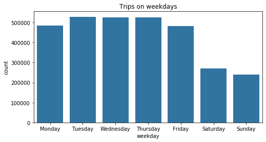

```python
# number of rides per weekday
plt.figure(figsize=[8,4]);
sns.countplot(data = data, x = 'weekday', color = base_color);
plt.title('Trips on weekdays');
#plt.xticks();
```

- Interestingly there are much more rides on working days than on weekend, indicating that the rides are more used for daily tasks (way to work) than for leisure.
- It would be of interest if there are more variables changing with weekdays.

### Hourly trip starts

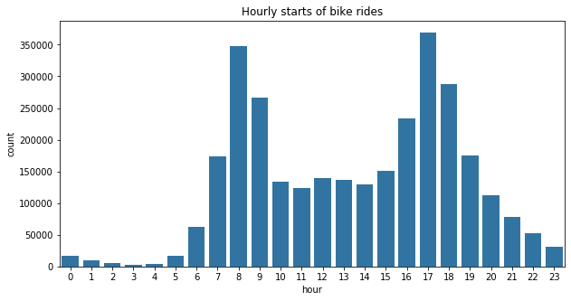

```python
# which time of day is the most traffic
plt.figure(figsize=[10,5]);
sns.countplot(data = data, x = 'hour', color = base_color);
plt.title('Hourly starts of bike rides');
```

- This distribution is bimodal, with maxima at 8h and 17h, probably the bikes are used for the ride to work.
- Also it is interesting that there is traffic at each hour, even at night.
- It would be interesting to compare this for the different weekdays.

## User data

### Age

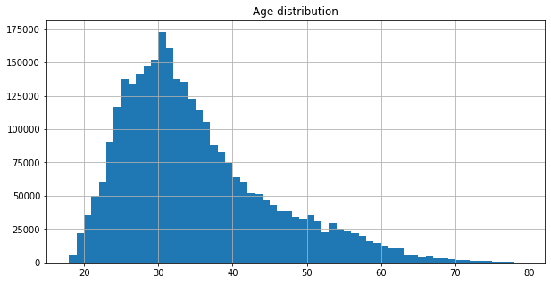

```python
# distribution of age
bin_edges = np.arange(18, 80, 1)
data.member_age.hist(bins=bin_edges, figsize=(10,5));
plt.title('Age distribution');
```

```python
data.member_age.describe()
```

```
count    3.060012e+06
mean     3.457622e+01
std      1.004306e+01
min      1.800000e+01
25%      2.700000e+01
50%      3.200000e+01
75%      4.000000e+01
max      7.900000e+01
Name: member_age, dtype: float64
```

```python
data.member_age.median()
```

```
32.0
```

- The age distribution is right skewed. The age ranges from 18 years, that is the minimum age for registring for the bikes, and 79 years. Higher ages have been cut from the preliminariy data in the cleaning section.
- The mean age is 34.5 years, median is 32 years, that is slightly below the median age given for the bay region
- Most of the users were between 20 and 40 years old.

```python
# setting age bins
# 18 to 30, 31 to 40, 41 to 50, 51 to 60, 61 to 70, 71 to 80

def grouping_age(x):
    if 18<=x<30:
        return('18-29')
    elif 30<=x<40:
        return('30-39')
    elif 40<=x<50:
        return('40-49')
    elif 50<=x<60:
        return('50-59')
    else:
        return('60-79')

data['age_group'] = data.member_age.apply(lambda x: grouping_age(x))
```

```python
age_proportions = data.groupby('age_group')['member_age'].count()/data.shape[0]
age_proportions
```

```
age_group
18-29    0.357368
30-39    0.390150
40-49    0.150944
50-59    0.078068
60-79    0.023470
Name: member_age, dtype: float64
```

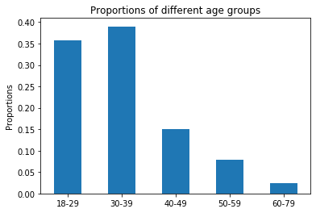

```python
age_proportions.plot(kind='bar');
plt.title('Proportions of different age groups');
plt.ylabel('Proportions');
plt.xlabel('');
plt.xticks(rotation=0);
```

### Gender

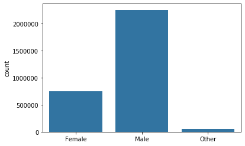

```python
sns.countplot(data=data, x='member_gender', color=base_color);
plt.xlabel('');
```

```python
# member gender
data.groupby('member_gender')['member_gender'].count()/data.shape[0]
```

```
member_gender
Female    0.245147
Male      0.738121
Other     0.016732
Name: member_gender, dtype: float64
```

- 73.8% of the users were male, only 24.5% female, 1.7% of the users declare themselves as other gender.
- This finding first was very astonishing, until I learned that there is a gender gap in cycling and these counts are consistent with the allover trend in USA.
- are there gender differences in bike usage?

### user type

```python
users = data.groupby('user_type')['user_type'].count()/data.shape[0]
users
```

```
user_type
Customer      0.111367
Subscriber    0.888633
Name: user_type, dtype: float64
```

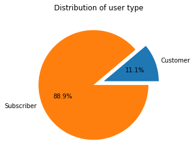

```python
explode = 0, 0.2
plt.pie(users, labels=users.index, explode=explode, autopct='%1.1f%%');
plt.axis('square');
plt.title('Distribution of user type');
# http://www.datasciencemadesimple.com/pie-chart-in-python-with-legends/
```

- 88.9% of the users are subscribers, only 11.1% are customer
- do the two user types differ in bike usage?
- do they differ in member structure?

#### Bike share for all trips

```python
# using bike share for all
share = data.groupby('bike_share')['bike_share'].count()/data.shape[0]
share
```

```
bike_share
No         0.908589
Unknown    0.001905
Yes        0.089506
Name: bike_share, dtype: float64
```

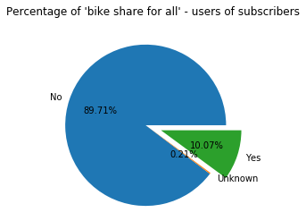

```python
# users of bike share were part of the subscription members.

subscriber = data[data.user_type=='Subscriber']
subscriber_props = subscriber.groupby('bike_share')['bike_share'].count()/subscriber.shape[0]

explode = 0, 0, 0.2
plt.pie(subscriber_props, labels=share.index, explode=explode, autopct='%1.2f%%');
plt.axis('square');
plt.title("Percentage of 'bike share for all' - users of subscribers");
```

Bike share for all trips is a special subscription with lower fees. People have to apply for it. Only about 10% of the users have this subscription.

### Discuss the distribution(s) of your variable(s) of interest. Were there any unusual points? Did you need to perform any transformations?

- The distribution of distance is heavily right skewed. For the display, the x-axis was limited.
- The distribution of duration also is heavily right skewed. Here, the x-axis was transformed to log scale for better display.
- examining daily and hourly counts of bike trips revealed some interesting patterns that are worth to be investigated more

## Bivariate Exploration

> The further exploration will focus on two points:
> - the customer and subscriber groups
> - the interesting usage patterns during day and week

### Structure of customer and subscriber group

#### Gender

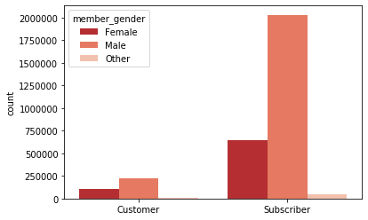

```python
sns.countplot(data = data, x = 'user_type', hue = 'member_gender', palette='Reds_r');
plt.xlabel('');
```

- the distribution of gender is similar in both groups

#### Age

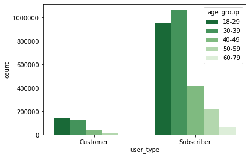

```python
age_order = ['18-29', '30-39', '40-49', '50-59', '60-79']

sns.countplot(data = data, x = 'user_type', hue = 'age_group', hue_order=age_order, palette='Greens_r');
```

- in both groups, the age up to 39 prevails.
- in customer group, there were slightly mor trips of age 18-29, whereas in subscriber group, most trips are of members age 30-39.

### Trip durations in relation to user group

```python
# user type an trip duration
data.groupby('user_type')['duration_min'].describe()

# shows a difference
```

| user_type | count | mean | std | min | 25% | 50% | 75% | max |
| --- | --- | --- | --- | --- | --- | --- | --- | --- |
| Customer | 340783.0 | 25.354824 | 66.842042 | 1.016667 | 9.050000 | 14.383333 | 23.133333 | 1436.800000 |
| Subscriber | 2719229.0 | 11.103587 | 21.615845 | 1.000000 | 5.483333 | 8.600000 | 13.116667 | 1438.016667 |

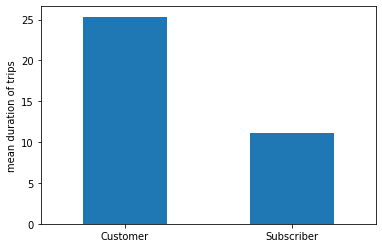

```python
data.groupby('user_type')['duration_min'].mean().plot.bar();
plt.ylabel('mean duration of trips');
plt.xticks(rotation=0);
plt.xlabel('');
```

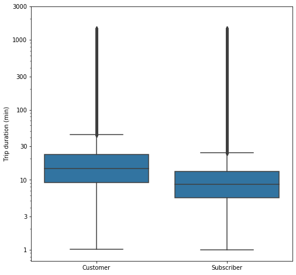

```python
plt.figure(figsize=[8, 8])
sns.boxplot(data = data, x = 'user_type', y='duration_min', color=base_color)
plt.yscale('log');
plt.xlabel('');
ylabels = [1, 3, 10, 30, 100, 300, 1000, 3000];
yticks = ylabels;
plt.yticks(yticks, ylabels);
plt.ylabel('Trip duration (min)');
```

- mean and median of trip duration are higher in customer than in subscriber group

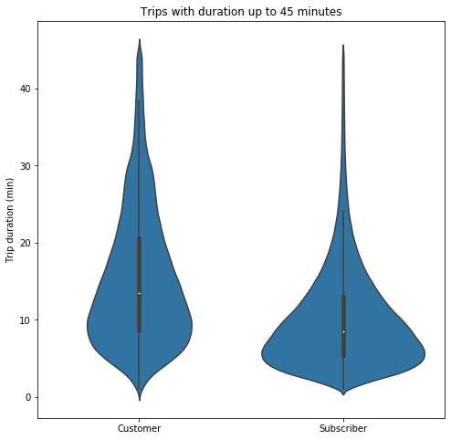

```python
short_trips=data[data.duration_min <= 45]

plt.figure(figsize=[8, 8])
sns.violinplot(data = short_trips, x = 'user_type', y='duration_min', color=base_color)
plt.xlabel('');
plt.title('Trips with duration up to 45 minutes');
plt.ylabel('Trip duration (min)');
```

- Here we clearly see that the customers and subscribers not only differ in mean and median but also in distribution of trip duration.
- while for subscribers there is a rather sharp maximum at around 5 minutes, the customers show a much broader peak at about 9 minutes and more variability.

### hourly trip starts depending on user type

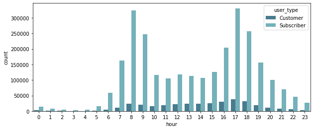

```python
# hour and user type
plt.figure(figsize=[10,4]);
sns.countplot(data = data, x = 'hour', hue = 'user_type', palette=base_palette);
# customer follows the trend of peaking at 8 and 17, where 17 is higher
```

### weekday usage depending on user type

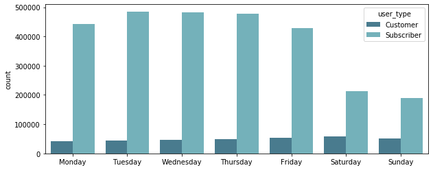

```python
# weekday usage depending on user type
plt.figure(figsize=[10, 4]);
sns.countplot(data = data, x = 'weekday', hue = 'user_type', palette = base_palette);
plt.xlabel('');
```

- the observed drop on trip counts at weekend comes from the subscriber group. - customers were similar active throughout the week, with increasing activity on weekends - Does the day of week have an influence on hourly trip counts?

### Influence of weekday on hourly trip start count

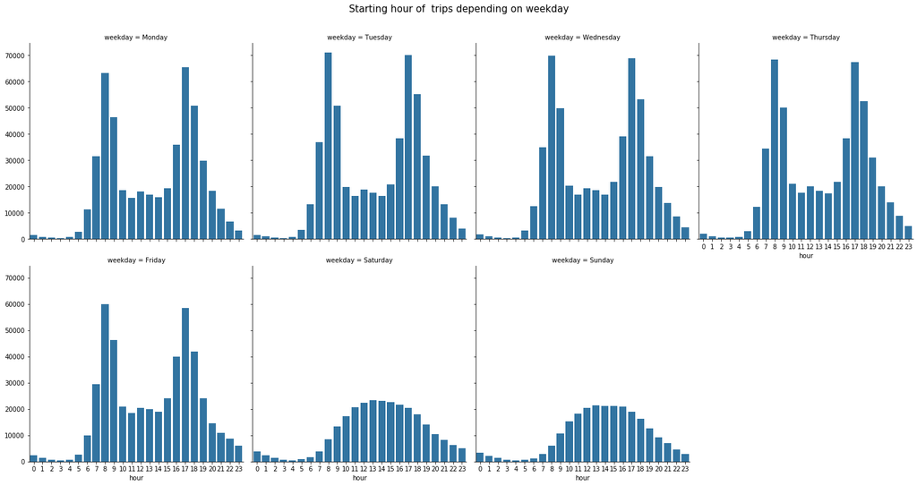

```python
g = sns.FacetGrid(data = data, col = 'weekday', col_order=weekdays, height = 5, col_wrap = 4, margin_titles = True);

g.fig.suptitle('Starting hour of  trips depending on weekday', y=1.05, size=15);
g.map(sns.countplot,'hour');
```

> trying the same as heatmap

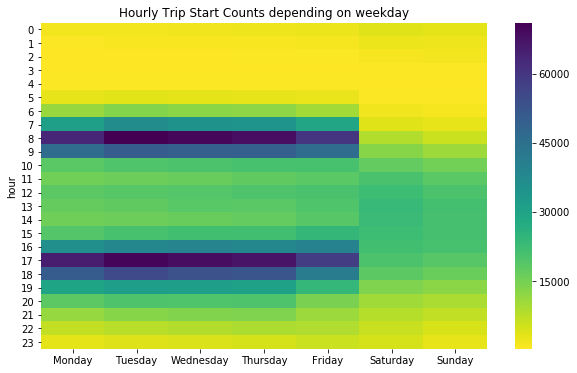

```python
# same as heatmap
plt.figure(figsize=[10,6]);

wd_counts = data.groupby(['weekday', 'hour']).size()
wd_counts = wd_counts.reset_index(name = 'count')
wd_counts = wd_counts.pivot(index = 'hour', columns = 'weekday', values = 'count')
sns.heatmap(wd_counts, cmap='viridis_r');
plt.title('Hourly Trip Start Counts depending on weekday');
plt.xlabel('');
plt.yticks(rotation=0);

# which is better? I think heatmap
```

- this heatmap clearly shows the peaks of trip counts at the rush hours on working days
- also there can clearly be seen that on weekends there is no sharp peak but a broad time range from late morning to the afternoon of high trip frequency

### Do other variables change with weekday or hour?

### Trip durations on day of week

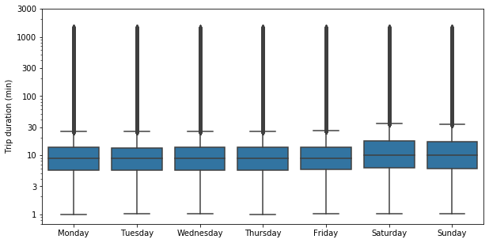

```python
plt.figure(figsize=[10, 5])
sns.boxplot(data = data, x = 'weekday', y='duration_min', color=base_color)
plt.yscale('log');
plt.xlabel('');
ylabels = [1, 3, 10, 30, 100, 300, 1000, 3000];
yticks = ylabels;
plt.yticks(yticks, ylabels);
plt.ylabel('Trip duration (min)');
```

Trip durations on weekends are longer and of more variability than on weekdays

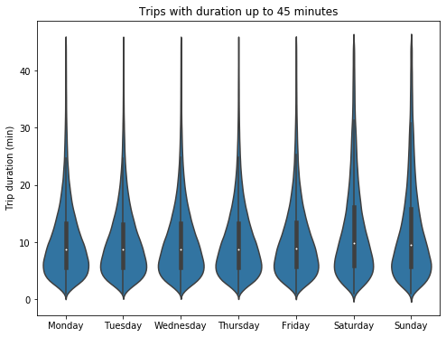

```python
plt.figure(figsize=[8, 6])
sns.violinplot(data = short_trips, x = 'weekday', y='duration_min', color=base_color)
plt.xlabel('');
plt.title('Trips with duration up to 45 minutes');
plt.ylabel('Trip duration (min)');
```

- we can see that the median of trip durations is slightly higher on weekend and also the variability

#### Does starting hour of the day has an influence on trip duration?

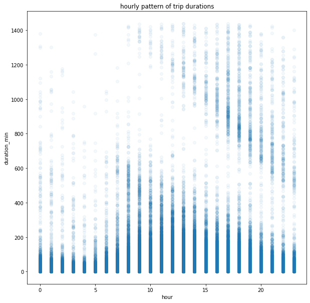

```python
# are there patterns on trip duration and hour?
plt.figure(figsize=[10,10]);
plt.scatter(data=data, x='hour', y='duration_min', alpha=0.05);
plt.title('hourly pattern of trip durations')
plt.xlabel('hour');
plt.ylabel('duration_min');
```

In the night, there mostly are short trips. We can see that bikes often were kept over night.(the diagonal gap)

#### Age distribution on weekdays

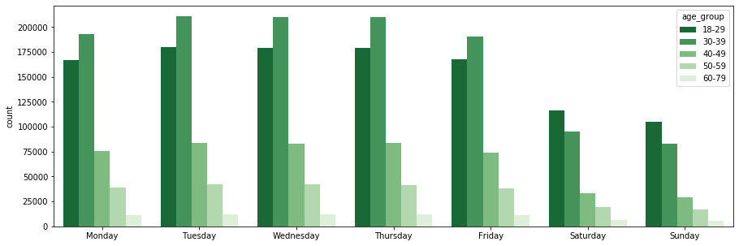

```python
# age and weekday
# age_order defined in line 142
plt.figure(figsize=[15,5]);

sns.countplot(data = data, x = 'weekday', hue = 'age_group', hue_order = age_order, palette='Greens_r');
plt.xlabel('');
```

- at all days, the members up to 39y are the most active.
- on working days, the most active group are the 30-39 years old
- on weekends, the younger members, 18-29 years, were mteh most active

#### Age distribution on trip start hours

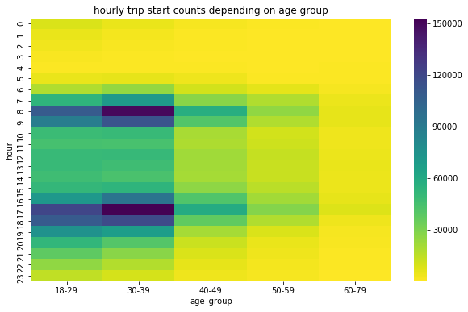

```python
# age and hour
plt.figure(figsize=[10,6])
ct_counts = data.groupby(['age_group', 'hour']).size()
ct_counts = ct_counts.reset_index(name = 'count')
ct_counts = ct_counts.pivot(index = 'hour', columns = 'age_group', values = 'count')
sns.heatmap(ct_counts, cmap='viridis_r')
plt.title('hourly trip start counts depending on age group');
```

- we can see that the count peaks around hours 8 and 17 are mostly induced by the younger age groups, especially the 30-39 years old, although the pattern is seen in every group.
- In the hours between the two peaks, trip counts of 18-29 and 30-39 years old are similar.
- We also can see some more activity of the youngest group in late night hours.